# Kostenoffenlegung als Wettbewerbsvorteil

Chancen und Potenziale der Kostentransparenz

# Motivation

Die Untersuchung von Kostentransparenz ist aus ökonomischer Sicht besonders spannend, da sie Einblicke in das Zusammenspiel von Marktverhalten, Preiswahrnehmung und Konsumentenvertrauen ermöglicht. In klassischen Märkten gilt Information als asymmetrisch verteilt - insbesondere Kostenstrukturen bleiben für Konsument:innen meist verborgen. Wenn Unternehmen jedoch freiwillig ihre Produktionskosten offenlegen, entsteht eine neue Form der Marktkommunikation, die sowohl auf das Kaufverhalten als auch auf die Markenbindung Einfluss nehmen kann.

In diesem Projekt beschäftigen Sie sich mit der ökonomischen Wirkung unterschiedlicher Formen von Kostentransparenz, darunter produktbezogene Einzelkosten-Offenlegung im Point-of-Sale oder auch verbal vermittelte Transparenz in Kombination mit Vertrauensmessung. Ziel ist es, zu untersuchen, wie sich diese Varianten auf Zahlungsbereitschaft, Vertrauen und wahrgenommene Preisfairness auswirken.

Kern dieser Ausarbeitung ist die Frage, inwiefern Kostentransparenz eine rationale Kaufentscheidung unterstützt oder über emotionale Mechanismen - etwa durch erhöhte Markenattraktivität - wirkt. Für die Analyse greifen Sie auf ein breites Methodenrepertoire zurück, das ökonomische Modellierung mit experimenteller Verhaltensforschung verbindet, und leisten so einen Beitrag zum besseren Verständnis moderner Konsumentenentscheidungen in transparenten Märkten. Für ihre Analyse verwenden Sie die Daten der folgenden Ausarbeitung:

**Mohan, B., Buell, R. W., & John, L. K. (2020). Lifting the veil: The benefits of cost transparency. Marketing Science, 39(6), 1105-1121.**

# Aufbau der Studie

1. Lesen Sie sich den folgenden Text zum Hintergrund und Aufbau der Studie durch und beantworten Sie nachfolgende Fragen dazu:

Der Ausgangspunkt der betrachteten Untersuchung war ein reales Ereignis: Ein Online-Händler stellte im Dezember 2013 ein hochwertiges Lederportemonnaie zum Verkauf. Einige Wochen später wurde auf den Produktseiten eine Infografik zur Kostenzusammensetzung ergänzt, allerdings versehentlich nur bei drei von fünf Farbvarianten. Obwohl der Händler diesen Fehler nicht beabsichtigte, entstand daraus ein sogenanntes natürliches Experiment, also eine reale Vergleichssituation mit kontrollierbaren Unterschieden. Die Verkäufe konnten analysiert werden, um zu überprüfen, ob die Offenlegung der Produktionskosten einen Einfluss auf das Kaufverhalten hatte.

Dieses natürliche Experiment lieferte erste Hinweise darauf, dass Kostentransparenz wirkt - und war damit die Basis für zwei gezielte Experimente im Labor, die Sie sich in diesem Projekt genauer anschauen sollen. Beide Laborexperimente knüpfen an die reale Ausgangslage an - gehen aber unterschiedliche Forschungsfragen an:

Experiment 1: In einem realitätsnahen Online-Setting wurde untersucht, ob Konsument:innen anders entscheiden, wenn sie Informationen zu Produktionskosten sehen. Hierbei sahen die Teilnehmer:innen eine Produktseite für einen Rucksack von Everlane - entweder mit oder ohne Kostenaufstellung (vgl. Abbildung 1: Kostentransparenz Infografik im Anhang). Zusätzlich wurde ein Vergleichsprodukt von J. Crew gezeigt (ohne Hinweise zur Kostenzusammensetzung). Die Teilnehmer:innen mussten entscheiden, von welchem Anbieter sie lieber einen Gutschein erhalten würden. Das Ziel der Forscher war es zu messen, ob Konsument:innen bei mehr Transparenz auch eher kaufen, folglich sich für diesen Gutschein entscheiden.

Experiment 2: Nachdem Experiment 1 zeigte, dass es einen Effekt der Kostentransparenz gibt, stellt sich die psychologische Anschlussfrage, warum es diesen Effekt gibt und wie dieser festzumachen ist. So sahen die Teilnehmer:innen im 2. Experiment ein fiktives Produkt - eine Schokoladentafel. In der Kontrollgruppe wurden nur übliche Produktinfos gezeigt. In der Treatmentgruppe gab es zusätzlich eine detaillierte Kostenaufstellung (vgl. Abbildung 2: Design der Schokoladenverpackung ohne und mit Kostentransparenz im Anhang). Im Anschluss wurden Vertrauen in die Marke und Kaufbereitschaft durch einen Fragebogen abgefragt. So sollte herausgefunden werden, ob Vertrauen der zentrale psychologische Mechanismus für die Kaufentscheidung der Kund:innen ist.

Beantworten Sie nun folgende Fragen:

1. Welches reale Ereignis war der Auslöser der Forschung?
2. Welche konkrete Verhaltensfrage steht im Mittelpunkt von Experiment 1 - Was wollten die Forscher:innen direkt am Kaufverhalten testen?
3. Welcher psychologische Faktor steht im Zentrum von Experiment 2 - und wie hängt er mit dem Kaufverhalten zusammen?

**Auslöser der Forschung:**

Der Ausgangspunkt der Forschung war ein reales Ereignis im Jahr 2013: Ein Online-Händler stellte ein hochwertiges Lederportemonnaie zum Verkauf. Einige Wochen später ergänzte er auf der Produktseite eine Infografik, die die Kostenzusammensetzung offenlegte. Aufgrund eines Fehlers erschien diese Infografik jedoch nur bei drei von fünf Farbvarianten.  
Durch diesen unbeabsichtigten Unterschied entstand ein sogenanntes natürliches Experiment – also eine reale Vergleichssituation mit kontrollierbaren Unterschieden. Dadurch konnten die Verkaufszahlen analysiert werden, um zu untersuchen, ob die Offenlegung der Produktionskosten das Kaufverhalten beeinflusst. Die Ergebnisse lieferten erste Hinweise darauf, dass Kostentransparenz tatsächlich eine Wirkung zeigt – und bildeten so die Grundlage für weiterführende Experimente im Labor.

**Verhaltensfrage zu Experiment 1**

Im Mittelpunkt von Experiment 1 stand die Frage, ob Konsument:innen ihr Kaufverhalten verändern, wenn sie Informationen über die Produktionskosten eines Produkts erhalten. Die Forscher:innen wollten konkret herausfinden, ob eine höhere Kostentransparenz dazu führt, dass sich Kund:innen eher für ein Produkt entscheiden – in diesem Fall gemessen daran, bei welchem Anbieter sie lieber einen Gutschein erhalten würden.  
Dazu wurde ein realistisches Online-Setting genutzt: Die Teilnehmer:innen sahen eine Produktseite für einen Rucksack von Everlane – einmal mit und einmal ohne Infografik zur Kostenaufstellung. Als Vergleich wurde zusätzlich ein Rucksack von J. Crew gezeigt, bei dem keine Informationen zur Kostenzusammensetzung angegeben waren. Die zentrale Verhaltensfrage lautete somit: Führt die Offenlegung von Produktionskosten dazu, dass Konsument:innen einem Anbieter mehr Vertrauen schenken und sich daher eher für dessen Produkt – oder in diesem Fall für das andere Produkt – entscheiden? Auf diese Weise wollten die Forscher:innen messbar machen, ob Transparenz beim Preis einen direkten Einfluss auf die Kaufentscheidung hat.

**Psychologischer Faktor von Experiment 2 und Zusammenhang des Kaufverhaltens**

Im Zentrum von Experiment 2 stand die Frage, warum Kostentransparenz das Kaufverhalten beeinflusst – also welcher psychologische Mechanismus diesem Effekt zugrunde liegt. Nachdem im ersten Experiment bereits festgestellt wurde, dass Transparenz bei Produktionskosten das Kaufverhalten positiv beeinflussen kann, wollten die Forscher:innen nun herausfinden, wie genau dieser Effekt entsteht.  
Dazu wurde ein fiktives Produkt – eine Schokoladentafel – genutzt. Die Teilnehmer:innen sahen entweder eine gewöhnliche Produktdarstellung (Kontrollgruppe) oder zusätzlich eine detaillierte Kostenaufstellung (Treatmentgruppe). Anschließend wurde mithilfe eines Fragebogens das Vertrauen in die Marke sowie die generelle Kaufbereitschaft abgefragt.  
Der zentrale psychologische Faktor in diesem Experiment war Vertrauen. Die Forscher:innen wollten untersuchen, ob Transparenz bei den Produktionskosten das Vertrauen der Konsument:innen stärkt – und ob dieses Vertrauen wiederum die Bereitschaft erhöht, ein Produkt zu kaufen. Es sollte also überprüft werden, ob Vertrauen der entscheidende Auslöser für das veränderte Kaufverhalten ist, das im ersten Experiment beobachtet wurde.

Nachdem Sie nun die grundlegende Forschungsidee und Zielsetzung der beiden Experimente kennengelernt haben, befassen wir uns im nächsten Schritt vertiefend mit Experiment 1. Ziel ist es, den genauen Aufbau, sowie das konkrete Verhalten der Teilnehmer:innen besser zu verstehen.

2. Lesen Sie sich den folgenden Text zum Aufbau des ersten Experiments durch und beantworten Sie anschließend Fragen dazu:

Cost transparency refers to the disclosure of the costs to produce a good or provide a service. Although cost transparency is a strategy traditionally employed in the context of supplier-firm relationships, wherein the two-way sharing of cost information between parties facilitates collaboration on cost reduction measures, we investigate its effects within the context of consumer-firm relationships. Information on the costs associated with providing goods and services is rarely shared with consumers, but we provide evidence of when and why voluntarily doing so can increase consumers’ purchase interest. Specifically, building on the psychology of disclosure and trust, we posit that cost transparency, insofar as it represents an act of intimate disclosure, fosters trust. In turn, we propose that this heightened trust increases consumers’ willingness to purchase from the transparent firm. In the sections that follow, we discuss our central predictions and highlight alternative accounts. Then, we present experiments, conducted in the lab and in the field, that document the main effects of cost transparency, its underlying psychological drivers, and conditions that moderate its effects.

This first experiment explores how cost transparency influences consumer preferences in an online shopping context. The study was designed as a between-subjects randomized experiment using an incentive-compatible setup, meaning participants made real choices with the possibility of receiving a tangible reward. A total of 509 U.S.-based participants were recruited through Amazon Mechanical Turk (MTurk). Each participant was randomly assigned to one of two experimental conditions:

- Cost Transparency Condition: Participants were shown a simulated product page for a backpack sold by the retailer Everlane. This page included a cost breakdown infographic, listing the production costs such as materials, labor, transport, and duties, with a clearly stated total cost.
- Control Condition: Participants saw the same backpack from Everlane but without any cost information. In both conditions, participants also saw a comparable backpack from J. Crew, which does not practice cost transparency.

Participants were instructed to view both product pages and then asked which company they would prefer to receive a $50 gift card from. Their response served as the main behavioral outcome, representing a choice between the transparent vs. non-transparent retailer. To ensure accurate interpretation of the presented information, a comprehension check followed the main choice question. Participants were also asked for demographic information such as age, gender, income, and education, to allow for potential control variables in later analysis.

Beantworten Sie nun folgende Fragen:

1. Wie viele Personen nahmen final an dem Experiment teil?
2. Worin bestand der Unterschied zwischen der Transparenzbedingung und der Kontrollbedingung?
3. Welche Anreizstruktur wurde verwendet, um die Entscheidung der Teilnehmenden realistisch zu gestalten?
4. Wie unterschieden sich die beiden gezeigten Onlinehändler im Experiment?
5. Warum wurde im Anschluss an die Entscheidungsfrage ein Verständnischeck durchgeführt?
6. In der Beschreibung des Experiments wird von “between-subjects randomized experiment using an incentive-compatible setup” gesprochen. Was versteht man hierunter im Detail?

*Hinweis:* Für die Beantwortung der letzten Frage können Sie [diesen Artikel (Seite 1-5)](https://www.researchgate.net/publication/268269783_Incentives_in_Experiments_A_Theoretical_Analysis) als Grundlage verwenden.

**Anzahl der Teilnehmenden**

Insgesamt nahmen 509 Personen an dem Experiment teil. Es handelte sich dabei um Teilnehmer:innen mit Wohnsitz in den USA, die über die Plattform Amazon Mechanical Turk (MTurk) rekrutiert wurden. Diese Zahl bezieht sich auf die final eingeschlossenen Teilnehmenden, also jene, deren Daten in die Auswertung aufgenommen wurden.

**Unterschied der Transparenzbedingung und der Kontrollbedingung**

Der zentrale Unterschied zwischen den beiden Bedingungen lag in der Darstellung der Produktionskosten:  
In der Transparenzbedingung (Cost Transparency Condition) sahen die Teilnehmer:innen eine simulierte Produktseite für einen Rucksack der Marke Everlane, auf der eine Infografik zur Kostenaufstellung eingeblendet war. Diese Grafik enthielt eine detaillierte Aufschlüsselung der Produktionskosten (z.B. für Materialien, Arbeit, Transport und Zölle) sowie den Gesamtkostenbetrag.  
In der Kontrollbedingung (Control Condition) wurde derselbe Rucksack von Everlane gezeigt – jedoch ohne jegliche Angaben zu den Produktionskosten.  
In beiden Bedingungen wurde zusätzlich ein vergleichbarer Rucksack von J. Crew angezeigt, der grundsätzlich keine Kostentransparenz praktiziert. So konnte beobachtet werden, ob und wie sich die Informationen zur Kostenzusammensetzung auf die Entscheidungspräferenzen auswirken.

**Verwendete Anreizstruktur**

Das Experiment verwendete eine sogenannte incentive-compatible setup (anreizkompatible Gestaltung). Das bedeutet, dass die Entscheidungen der Teilnehmer:innen reale Konsequenzen haben konnten – in diesem Fall die Möglichkeit, tatsächlich einen $50-Geschenkgutschein zu erhalten.  
Durch diesen realen Anreiz wurde sichergestellt, dass die Teilnehmer:innen ernsthafte und authentische Entscheidungen treffen, anstatt hypothetische oder willkürliche Angaben zu machen. Solche Designs erhöhen die ökologische Validität eines Experiments, da sie realitätsnähere Entscheidungsverhalten fördern.

**Unterscheidung der Onlinehändler**

Die beiden Onlinehändler Everlane und J. Crew unterschieden sich im Experiment in einem entscheidenden Punkt:  
- Everlane ist ein Anbieter, der Kostentransparenz praktiziert, d.h. der offenlegt, wie sich der Preis eines Produkts zusammensetzt. In der Transparenzbedingung wurde dies durch die Darstellung einer Kostenaufstellung auf der Produktseite visualisiert.  
- J. Crew hingegen stellte keine Informationen zur Kostenzusammensetzung zur Verfügung. Dies spiegelt den realen Marktunterschied zwischen beiden Marken wider und diente im Experiment als Kontrast: ein transparenter Anbieter versus ein nicht-transparenter Anbieter.  
Die Teilnehmer:innen mussten sich also für einen $50-Gutschein eines der beiden Anbieter entscheiden – ihre Wahl spiegelte somit eine Präferenz zwischen einem transparenten und einem nicht-transparenten Unternehmen wider.

**Ursache des Verständnischecks**

Der Verständnischeck (comprehension check) diente dazu sicherzustellen, dass die Teilnehmer:innen die gezeigten Informationen auf den Produktseiten richtig verstanden und verarbeitet hatten.  
Dies ist wichtig, um die Validität der Ergebnisse zu sichern. Denn nur wenn die Teilnehmer:innen die Unterschiede zwischen den Bedingungen (insbesondere die Kostentransparenz) tatsächlich wahrgenommen haben, kann eine fundierte Aussage darüber getroffen werden, ob und wie diese Informationen ihre Entscheidung beeinflusst haben.  
Der Verständnischeck hilft außerdem dabei, unaufmerksame Teilnehmer:innen herauszufiltern, deren Daten andernfalls die Analyse verzerren könnten.

**Verständnis der Beschreibung**

Ein „between-subjects randomized experiment using an incentive-compatible setup“ setzt sich aus drei zentralen Konzepten zusammen, die im Folgenden erläutert werden:

1. Between-Subjects Design  
   Ein Between-Subjects-Design bedeutet, dass jede Versuchsperson nur einer einzigen Bedingung des Experiments zugewiesen wird – in diesem Fall entwederder Transparenzbedingung oder der Kontrollbedingung.  
   Vorteil dieses Designs ist, dass keine Übertragungseffekte zwischen den Bedingungen auftreten können (z.B. dass Teilnehmer:innen durch den Vergleich selbst misstrauisch oder neugierig werden). Dadurch können kausale Aussagen über den Effekt der Manipulation (Kostentransparenz) gemacht werden.
2. Randomized Experiment  
   Die Zuteilung der Teilnehmenden zu den Bedingungen erfolgt zufällig (randomisiert). Das stellt sicher, dass systematische Unterschiede zwischen den Gruppen vermieden werden, z.B. in Bezug auf Alter, Einkommen oder Einstellungen.  
   Durch diese Randomisierung sind unterschiedliche Ergebnisse zwischen den Gruppen tatsächlich auf die experimentelle Manipulation zurückzuführen – und nicht auf andere Faktoren.
3. Incentive-Compatible Setup  
   Ein incentive-kompatibles Design bedeutet, dass die Teilnehmer:innen in einer Weise entscheiden, die für sie reale Konsequenzen haben kann. In diesem Fall konnten sie tatsächlich einen $50-Gutschein gewinnen – je nachdem, welchen Anbieter sie gewählt hatten.  
   Die Idee hinter diesem Ansatz ist, dass Menschen realistischere und ehrlichere Entscheidungen treffen, wenn sie einen echten Anreiz haben – wie in der realen Welt, wo Kaufentscheidungen ebenfalls finanzielle Konsequenzen haben.  
   Laut dem verlinkten Artikel („Incentives in Experiments – A Theoretical Analysis“) ist die Verwendung von realen Anreizen besonders dann wichtig, wenn das Verhalten der Teilnehmer:innen nicht nur hypothetisch, sondern realitätsnah sein soll. Dabei wird davon ausgegangen, dass Menschen rationale Entscheidungen treffen, wenn sie einen Nutzen maximieren wollen – also z.B. den für sie besseren Gutschein erhalten.

# Daten

## Datenimport und -aufbereitung

Die Daten, die Sie für die nachfolgenden Analysen verwenden, wurden zu Replikationszwecken von den Autoren der Studie zur Verfügung gestellt und können hier heruntergeladen werden:

**Bhavya Mohan, Ryan W. Buell, Leslie K. John (2020) Lifting the Veil: The Benefits of Cost Transparency. Marketing Science 39(6):1105-1121. mksc.2019.1200.sm1.pdf**

Wir haben die Daten für Sie heruntergeladen und im Unterordner mit dem Namen `Daten` bereitgestellt. Für ihre Analyse werden die Dateien `Experiment1.csv` und `Experiment2.csv` genutzt. Für die Zusatzaufgabe ist die Datei `Experiment3.csv` relevant.

3. Lesen Sie den Datensatz `Experiment1.csv` aus dem Unterordner `Daten` in R ein. Nennen Sie den Datensatz in R `daten_exp1`.

Im Datensatz sind unterschiedliche Variablen enthalten. Weiterhin habe wir Ihnen ein Readme mit den Beschreibungen zu den Variablen bereitgestellt. Nutzen Sie dieses und den Text aus Aufgabe 2, um die Variablen zu beschreiben.

**Beschreibung der Variablen:**

treatment:

- Typ: Dichotome Variable (0/1)
- Skalierung:
  - 1 = Die Teilnehmer:in wurde der Behandlungsgruppe zugewiesen und sah die Everlane-Seite mit Kostentransparenz-Infografik.
  - 0 = Die Teilnehmer:in war in der Kontrollgruppe und sah die Everlane-Seite ohne Kostenaufstellung.
- Bedeutung: Diese Variable zeigt, welche Version der Produktseite (transparent vs. nicht transparent) ein:e Teilnehmer:in gesehen hat.
- Rolle im Experiment: Sie ist die unabhängige Variable, die die experimentelle Manipulation repräsentiert.
- Funktion in der Auswertung: Diese Variable wird genutzt, um den kausalen Einfluss von Transparenz auf das Konsumentenverhalten (z.B. Gutscheinwahl) zu messen.

everlane:

- Typ: Dichotome Variable (0/1)
- Skalierung:
  - 1 = Teilnehmer:in hat sich für den Everlane-Gutschein entschieden.
  - 0 = Teilnehmer:in hat sich für den J. Crew-Gutschein entschieden.
- Bedeutung: Diese Variable misst die Verhaltensreaktion der Teilnehmer:innen auf die zuvor gezeigten Produktseiten.
- Rolle im Experiment: Sie ist die abhängige Variable, die angibt, ob sich ein:e Teilnehmer:in für den transparenten Anbieter (Everlane) entschieden hat.
- Funktion in der Auswertung: Wird verwendet, um zu analysieren, ob und wie sich Kostentransparenz (treatment) auf die tatsächliche Kaufpräferenz auswirkt.

passed:

- Typ: Dichotome Variable (0/1)
- Skalierung:
  - 1 = Verständnischeck bestanden
  - 0 = Verständnischeck nicht bestanden
- Bedeutung: Gibt an, ob Teilnehmer:innen die Inhalte der Produktseiten (insbesondere zur Kostentransparenz) richtig verstanden haben.
- Rolle im Experiment: Qualitätskontrollvariable – sie hilft sicherzustellen, dass nur Daten von Teilnehmer:innen analysiert werden, die die Manipulation korrekt wahrgenommen haben.
- Funktion in der Auswertung: Kann genutzt werden, um Teilnehmer:innen mit unklarer Datenlage auszuschließen oder als Kontrollvariable, um die Robustheit der Haupteffekte zu testen.

email_provided:

- Typ: Dichotome Variable (0/1)
- Skalierung:
  - 1 = E-Mail-Adresse wurde angegeben
  - 0 = Keine E-Mail-Adresse angegeben
- Bedeutung: Zeigt, ob die Teilnehmer:innen bereit waren, eine E-Mail für den Erhalt eines echten Gutscheins zu hinterlassen.
- Rolle im Experiment: Indikator für die Ernsthaftigkeit und Glaubwürdigkeit der Teilnahme.
- Funktion in der Auswertung: Kann verwendet werden, um Analysen auf Teilnehmer:innen zu beschränken, die realistische Entscheidungen getroffen haben (anreizkompatibel).

female:

- Typ: Dichotome Variable (0/1)
- Skalierung:
  - 1 = weiblich
  - 0 = männlich
- Bedeutung: Selbstberichtetes Geschlecht der Teilnehmenden.
- Rolle im Experiment: Soziodemografische Variable
- Funktion in der Auswertung: Wird genutzt, um Geschlechterunterschiede im Entscheidungsverhalten zu analysieren oder als Kontrollvariable in Regressionsmodellen.

age:

- Typ: Numerische Variable (offene Eingabe, z.B. 28, 45, …)
- Bedeutung: Alter der Teilnehmer:innen in Jahren (selbst angegeben).
- Rolle im Experiment: Soziodemografische Hintergrundvariable
- Funktion in der Auswertung: Dient zur Untersuchung altersbedingter Effekte (z.B. sind jüngere Personen eher empfänglich für Transparenz?) oder zur statistischen Kontrolle.

educ:

- Typ: Ordinal skalierte Variable (1–5)
- Skalierung:
  - 1 = Einige Jahre Schule
  - 2= Schulabschluss
  - 3= Einige Jahre College
  - 4 = Hochschulabschluss
  - 5 = Postgradual / beruflich
- Bedeutung: Höchster Bildungsabschluss der Teilnehmer:innen.
- Rolle im Experiment: Soziodemografische Variable zur Analyse von Bildungseinflüssen auf das Vertrauen oder die Kaufentscheidung.
- Funktion in der Auswertung: Als Kontroll- oder Moderationsvariable einsetzbar (z.B. wirken Informationen bei höherem Bildungsniveau stärker?).

income:

- Typ: Ordinal skalierte Variable (1–12)
- Skalierung:
  - 1 = Kein Einkommen
  - 2 = Unter 60 Dollar
  - 3 = 60–499 Dollar
  - 4 = 500–999 Dollar
  - 5 = 1.000–1.999 Dollar
  - 6 = 2.000–2.999 Dollar
  - 7 = 3.000–3.999 Dollar
  - 8 = 4.000–4.999 Dollar
  - 9 = 5.000–7.499 Dollar
  - 10 = 7.500–9.999 Dollar
  - 11 = Über 10.000 Dollar
  - 12 = Weiß nicht / Bevorzuge keine Antwort
- Bedeutung: Selbst eingeschätztes monatliches Einkommen der Teilnehmer:innen.
- Rolle im Experiment: Dient zur Erfassung der ökonomischen Situation der Teilnehmer:innen.
- Funktion in der Auswertung: Als Kontrollvariable, um zu prüfen, ob Einkommensniveaus Kaufpräferenzen oder die Wirkung von Transparenz beeinflussen.

## Deskriptive Analyse

Sie sollten sich im ersten Schritt einen Überblick über ihre Daten verschaffen.

4. Auf Basis des Datensatzes `daten_exp1` aus Aufgabe 3 erstellen Sie eine deskriptive Tabelle mit der Anzahl an Beobachtungen, den Mittelwerten, der Standardabweichungen, dem Median, sowie den Minima und Maxima für alle in `daten_exp1` enthaltenen Variablen.

Beschreiben und interpretieren Sie ihre Tabelle. Gehen Sie insbesondere auf die Verteilungen der einzelnen Variablen ein. Was fällt hier besonders auf.

**Deskriptive Statistik – Standarddatensatz**

| Variable | N | Mittelwert | Standardabw. | Median | Minimum | Maximum | Anzahl Ja (1) | Anzahl Nein (0) |
| --- | --- | --- | --- | --- | --- | --- | --- | --- |
| Kostentransparenz (1=Ja, 0=Nein – treatment) | 509 | 0.50 | 0.50 | 0.00 | 0.00 | 1.00 | 253 | 256 |
| Wahl Everlane-Gutschein (1=Ja, 0=Nein – everlane) | 509 | 0.63 | 0.48 | 1.00 | 0.00 | 1.00 | 319 | 190 |
| Verständnistest bestanden (1=Ja, 0=Nein – passed) | 509 | 0.77 | 0.42 | 1.00 | 0.00 | 1.00 | 394 | 115 |
| E-Mail angegeben (1=Ja, 0=Nein – email_provided) | 509 | 0.56 | 0.50 | 1.00 | 0.00 | 1.00 | 285 | 224 |
| Geschlecht: weiblich (1=Ja, 0=Nein – female) | 509 | 0.49 | 0.50 | 0.00 | 0.00 | 1.00 | 247 | 262 |
| Alter (Jahre – age) | 505 | 37.59 | 11.74 | 35.00 | 18.00 | 81.00 | NA | NA |
| Bildungsabschluss (1–5 – educ) | 505 | 3.76 | 0.84 | 4.00 | 1.00 | 5.00 | NA | NA |
| Monatl. Einkommen (Kategorie 1–12 – income) | 505 | 7.58 | 2.43 | 8.00 | 1.00 | 12.00 | NA | NA |

*Hinweis: Die letzten 3 Variablen besitzen größere Zahlenbereiche als 0/1*

**Interpretation der Tabelle**

Die Tabelle zeigt die deskriptiven Statistiken (Anzahl, Mittelwert, Standardabweichung, Median, Minimum, Maximum, Anzahl Ja / Nein für Variablen, die dichtonom sind) für die wichtigsten Variablen (treatment, everlane, passed, email_provided, female, age, educ, income) des 1. Experiments mit insgesamt 509 Teilnehmer:innen. Dabei gibt es bei den 3 letzten Variablen (age, educ, income) unvollständige Werte, da die Anzahl hier nur 505 beträgt. Im Folgenden wird die Verteilung der einzelnen Variablen beschrieben und interpretiert. Dabei werden Auffälligkeiten hervorgehoben.

**Kostentransparenz (treatment)**

Die Variable zur Kostentransparenz ist eine dichotome Variable mit den Werten 0 (Kontrollgruppe ohne Kostenaufstellung) und 1 (Behandlungsgruppe mit Kostentransparenz). Die Verteilung ist mit einem Mittelwert von 0,50 nahezu ausgeglichen: 253 Teilnehmer:innen waren in der Transparenzgruppe, 256 in der Kontrollgruppe. Das zeigt, dass die Randomisierung gut funktioniert hat und die Gruppen gleich groß sind. Damit ist gewährleistet, dass eventuelle Unterschiede in der Kaufpräferenz auf die experimentelle Manipulation zurückgeführt werden können und keine Verzerrungen in der Gruppenzusammensetzung vorliegen.

**Wahl Everlane-Gutschein (everlane)**

Die abhängige Variable, die misst, ob sich die Teilnehmer:innen für den Everlane-Gutschein (1) oder den J. Crew-Gutschein (0) entschieden haben, weist einen Mittelwert von 0,63 auf. Das bedeutet, dass 63 % der Teilnehmer:innen den Gutschein des transparenten Anbieters Everlane bevorzugten. Diese Mehrheit deutet darauf hin, dass Kostentransparenz insgesamt positiv aufgenommen wurde oder zumindest Everlane gegenüber J. Crew einen gewissen Präferenzvorteil besitzt. Die Standardabweichung von 0,48 entspricht der erwarteten Streuung bei binären Variablen mit ungleicher Verteilung. Um den direkten Einfluss der Kostentransparenz zu untersuchen, sind weitere Analysen notwendig, aber der erste Eindruck lässt vermuten, dass Transparenz die Präferenz für Everlane stärkt.

**Verständnistest bestanden (passed)**

77 % der Teilnehmenden bestanden den Verständnischeck, was darauf hinweist, dass die Mehrheit der Proband:innen die präsentierten Informationen zur Kostentransparenz richtig erfasst hat. Dies ist wichtig, um sicherzustellen, dass die experimentelle Manipulation von den Teilnehmer:innen wahrgenommen wurde. Die verbleibenden 23 % könnten die Ergebnisse verwässern, falls sie die Manipulation nicht verstanden haben. Daher ist die Variable „passed“ auch als Filter- oder Kontrollvariable sinnvoll, um die Datenqualität zu erhöhen und die Ergebnisse robuster zu machen.

**E-Mail angegeben (email_provided)**

56 % der Teilnehmenden waren bereit, eine E-Mail-Adresse anzugeben, um einen echten Gutschein zu erhalten. Dies ist ein Hinweis darauf, dass mehr als die Hälfte der Teilnehmer:innen das Experiment ernst genommen und eine reale Entscheidung getroffen hat. Die variable E-Mail-Angabe kann somit genutzt werden, um Analysen auf Personen zu beschränken, die sich an die anreizkompatible Aufgabe gebunden fühlten. Teilnehmer:innen ohne E-Mail-Angabe könnten weniger motiviert oder skeptisch gewesen sein.

**Geschlecht (female)**

Die Verteilung der Geschlechter ist mit 49 % weiblichen und 51 % männlichen Teilnehmenden sehr ausgewogen. Dadurch ist die Stichprobe gut geeignet, um mögliche Geschlechterunterschiede in der Reaktion auf Kostentransparenz zu untersuchen. Die Standardabweichung von 0,50 entspricht der erwarteten Varianz bei einer dichotomen Variable mit fast gleichen Gruppen.

**Alter (age)**

Das durchschnittliche Alter der Stichprobe liegt bei 37,6 Jahren, mit einem Median von 35 Jahren. Die Spanne reicht von 18 bis 81 Jahren, und die Standardabweichung von 11,74 zeigt eine relativ breite Streuung. Das bedeutet, dass sowohl junge als auch ältere Personen in der Stichprobe vertreten sind, was die Untersuchung altersbezogener Effekte auf die Wahrnehmung von Kostentransparenz erlaubt. Die leichte Differenz zwischen Mittelwert und Median deutet auf eine leichte Rechtsverschiebung (einige ältere Teilnehmer:innen) hin.

**Bildungsabschluss (educ)**

Die Teilnehmenden weisen überwiegend einen hohen Bildungsabschluss auf: Der Median liegt bei 4 (Hochschulabschluss) und der Mittelwert bei 3,76, was knapp darunter liegt. Die Skala reicht von 1 („einige Jahre Schule“) bis 5 („postgradual / beruflich“), somit sind die meisten Personen mindestens mit einigen Jahren College-Erfahrung vertreten. Diese hohe Bildung könnte dazu beitragen, dass die Teilnehmenden die Kostentransparenz-Informationen besser verstehen und verarbeiten konnten, was mit der hohen Bestehensquote im Verständnischeck korreliert.

**Monatliches Einkommen (income)**

Das monatliche Einkommen der Teilnehmenden verteilt sich relativ breit auf der Skala von 1 (kein Einkommen) bis 12 (weiß nicht / keine Antwort). Der Median liegt bei 8, was der Kategorie 4.000–4.999 Dollar entspricht. Die Standardabweichung ist mit 2,43 vergleichsweise hoch, was auf eine große Streuung der Einkommensverhältnisse hinweist. Eine solche Varianz ist hilfreich, um zu prüfen, ob das Einkommen einen moderierenden Einfluss auf die Wirkung von Kostentransparenz hat. Insgesamt ist die Stichprobe eher in der mittleren Einkommensklasse angesiedelt.

**Gesamtfazit:**

Die deskriptiven Daten zeigen, dass das Experiment auf einer soliden Grundlage steht: Die Randomisierung der Treatment-Gruppen ist gelungen, die Stichprobe ist heterogen hinsichtlich Alter und Einkommen, aber eher gut gebildet. Die Mehrheit der Teilnehmenden versteht die Manipulation und trifft ernsthafte Entscheidungen, was die Validität der Ergebnisse stützt. Der hohe Anteil der Everlane-Wahl (63 %) liefert einen ersten Hinweis darauf, dass Kostentransparenz die Präferenz für diesen Anbieter stärkt, was mit den theoretischen Annahmen übereinstimmt. Weitere statistische Analysen sind notwendig, um den kausalen Einfluss genauer zu untersuchen.

5. Im Datensatz `daten_exp1` gibt es Variablen für die keine Beobachtungen vorhanden sind.
- Gegeben ihrer Variablenbeschreibung in Aufgabe 3:
  - Macht es Sinn die Beobachtungen aus dem Datensatz zu entfernen, wenn für bestimmte Variablen keine Werte vorhanden sind?
  - Wenn ja, warum?
  - Wie viele Beobachtungen entfernen Sie dadurch aus ihrem Datensatz?

Entfernen Sie nun alle Beobachtungen (d.h. gesamte Zeilen aus dem Datensatz), bei denen für mindestens eine der erhobenen Variablen kein Wert vorliegt, da unvollständige Daten für die Analyse nicht berücksichtigt werden sollen.

Untersuchen Sie weiterhin, ob sich die Teilnehmer, die die Webseite mit der Kostentransparenz gesehen haben (Treatmentgruppe), systematisch von jenen unterscheiden, die die Kontrollversion gesehen haben. Auch wenn es sich um ein Experiment handelt, bei dem die Zuteilung zu den Gruppen zufällig erfolgt ist, sollten Sie dennoch prüfen, ob es unbeabsichtigte (systematische) Unterschiede zwischen den Gruppen gibt. Erstellen Sie hierfür eine Balancing-Tabelle, in der Sie die Mittelwerte von Alter (age), Geschlecht (female), Einkommensstufe (income) und Bildungsniveau (educ) zwischen den beiden Gruppen vergleichen, die Differenzen berechnen und mithilfe von T-Tests prüfen, ob diese Unterschiede statistisch signifikant sind.

- Beschreiben und interpretieren Sie ihre Tabelle.
  - Was fällt Ihnen in Bezug auf die p-Werte auf?
  - Was müssten Sie bei einer weiteren Regressionsanalyse berücksichtigen?

*Hinweis:* Die beiden Gruppen, die Sie in der Balancing Tabelle betrachten sollen, können aus den Werten (1 und 0) der Variable `treatment` abgeleitet werden.

**Balancing-Tabelle: Vergleich Treatment- vs. Kontrollgruppe**

| Variable | Mittelwert Treatment | Mittelwert Kontrolle | Differenz | p-Wert |
| --- | --- | --- | --- | --- |
| Alter (age) | 37.27 | 37.91 | −0.64 | 0.5409 |
| Geschlecht: weiblich (female) | 0.49 | 0.49 | 0.00 | 0.9638 |
| Einkommen (income) | 7.76 | 7.40 | 0.36 | 0.0976 |
| Bildung (educ) | 3.79 | 3.73 | 0.06 | 0.4185 |

*Hinweis: p-Werte stammen aus T-Tests zwischen Treatment- und Kontrollgruppe*

**Unvollständige Variablen**

Ja es macht durchaus Sinn, Beobachtungen mit fehlenden Werten zu entfernen. Diese Beobachtungen könnten allgmein die Stichprobe verzerren und daher im weiteren Verlauf der Analyse wie beispielsweise bei Regressionen und Mittelwerten zu Problemen führen. Werden diese Beobachtungen bereinigt, so kann eine verzerrungsfreie Schätzung eher gewährleistet werden. In diesen Datensatz sind insgesamt 4 Beobachtungen unvollständig und somit werden diese auch in dem Datensatz bereinigt. Nach der Bereinigung befinden sich im Datensatz nur noch 505 nutzbare Beobachtungen, mit welchen im weiteren Projekt gearbeitet wird.

**Beschreibung der Tabelle**

Die Tabelle zeigt einen Vergleich zwischen zwei Gruppen von Teilnehmer:innen im Experiment: der Treatmentgruppe (treatment = 1), die die Produktseite mit Kostentransparenz gesehen hat, und der Kontrollgruppe (treatment = 0), die die Produktseite ohne Kostentransparenz sah.  
Für beide Gruppen werden folgende Merkmale dargestellt:

- Alter (age): Durchschnittliches Alter in Jahren
- Geschlecht (female): Anteil weiblicher Teilnehmer:innen (1 = weiblich, 0 = männlich)
- Einkommen (income): Durchschnittliche Einkommenskategorie (ordinal von 1 bis 12)
- Bildung (educ): Durchschnittliches Bildungsniveau (ordinal von 1 bis 5)

Für jede Variable zeigt die Tabelle:

- Den Mittelwert in der Treatmentgruppe
- Den Mittelwert in der Kontrollgruppe
- Die Differenz der Mittelwerte (Treatment minus Kontrolle)
- Den p-Wert eines unabhängigen T-Tests, der prüft, ob die Mittelwertdifferenz statistisch signifikant ist

**Interpretation der Tabelle**

- Alter: Das durchschnittliche Alter liegt bei etwa 37 Jahren in beiden Gruppen. Die Differenz beträgt nur −0,64 Jahre, also kaum nennenswert. Der p-Wert von ca. 0,54 zeigt, dass dieser kleine Unterschied zufällig sein kann und keine systematische Abweichung vorliegt.
- Geschlecht: In beiden Gruppen sind rund 49 % der Teilnehmer:innen weiblich. Die Differenz ist exakt 0.00, was eine perfekte Übereinstimmung bedeutet. Der p-Wert von ca. 0,96 bestätigt, dass die Verteilung des Geschlechts in beiden Gruppen identisch ist.
- Einkommen: Die Treatmentgruppe hat einen leicht höheren durchschnittlichen Einkommenwert (7,76 vs. 7,40). Die Differenz von 0,36 auf der 1–12-Skala deutet auf einen kleinen Unterschied hin. Der p-Wert liegt bei ca. 0,098, was nahe an der Grenze zur Signifikanz (0,05) ist, aber formal nicht als statistisch signifikant gilt.
- Bildung: Der durchschnittliche Bildungswert ist in beiden Gruppen ähnlich (3,79 vs. 3,73). Die Differenz von 0,06 ist sehr gering, und der p-Wert von ca. 0,42 zeigt, dass dieser Unterschied zufällig ist.

**Auffälligkeiten der p-Werte**

Die p-Werte zeigen, ob die beobachteten Unterschiede zwischen Treatment- und Kontrollgruppe statistisch signifikant sind. Hier fallen folgende Punkte auf:

- Für Alter, Geschlecht und Bildung sind die p-Werte mit Werten deutlich über 0,05 sehr hoch. Das bedeutet, dass keine statistisch signifikanten Unterschiede zwischen den Gruppen in diesen Variablen vorliegen. Die zufällige Zuteilung des Experiments scheint also in Bezug auf diese Merkmale gut funktioniert zu haben.
- Beim Einkommen ist der p-Wert mit ca. 0,098 vergleichsweise niedrig, aber immer noch größer als 0,05. Das lässt vermuten, dass hier eine leichte Tendenz zu einem Unterschied besteht, aber dieser ist statistisch nicht eindeutig signifikant. Je nach wissenschaftlicher Konvention könnte man dies als einen Hinweis auf eine mögliche systematische Differenz betrachten, die man im Hinterkopf behalten sollte.

Insgesamt zeigen die p-Werte, dass die Randomisierung im Experiment gut gelungen ist und die Gruppen im Durchschnitt vergleichbar sind. Die geringe Einkommensdifferenz könnte jedoch eine Ausnahme sein, die weiter beobachtet werden sollte.

**Berücksichtigung bei weiteren Regressionsanalysen**

Bei einer weiterführenden Regressionsanalyse, in der geprüft werden soll, wie Kostentransparenz (treatment) die Wahl des Everlane-Gutscheins (everlane) beeinflusst, sind folgende Punkte wichtig:

- Einbeziehung von Kontrollvariablen: Obwohl Alter, Geschlecht und Bildung statistisch nicht unterschiedlich sind, können sie das Konsumentenverhalten beeinflussen. Es empfiehlt sich daher, diese Variablen als Kontrollgrößen in das Regressionsmodell aufzunehmen, um den Einfluss von Kostentransparenz auf die Gutscheinwahl präzise zu schätzen und mögliche Störfaktoren auszuschließen.
- Einkommen besonders beachten: Da Einkommen eine leichte (tendenzielle) Differenz aufweist, sollte diese Variable auf jeden Fall als Kontrollvariable einbezogen werden. So wird vermieden, dass eventuelle Effekte von Kostentransparenz durch Unterschiede im Einkommen verzerrt werden.
- Robustheit der Ergebnisse: Die Kontrollvariablen helfen, die Robustheit der Schätzung zu erhöhen. Das heißt, man kann sicherer sein, dass ein gefundener Effekt wirklich auf die Kostentransparenz zurückzuführen ist und nicht auf systematische Unterschiede in den demografischen Merkmalen.
- Prüfung von Interaktionseffekten: Es kann sinnvoll sein, zu untersuchen, ob der Effekt von Kostentransparenz auf die Kaufentscheidung für unterschiedliche Gruppen unterschiedlich stark ist. Beispielsweise könnte man Interaktionsterms zwischen treatment und income, age, female oder educ in das Modell aufnehmen, um Moderationseffekte zu prüfen.
- Umgang mit fehlenden Daten: Da im Datensatz fehlende Werte in einzelnen Variablen entfernt wurden, sollte man in der Regressionsanalyse ebenfalls nur vollständige Fälle verwenden oder geeignete Verfahren (wie Multiple Imputation) anwenden, um Verzerrungen durch fehlende Daten zu vermeiden.
- Interpretation der Kausaleffekte: Da es sich um ein randomisiertes Experiment handelt, kann der geschätzte Einfluss von Kostentransparenz als kausaler Effekt interpretiert werden, vorausgesetzt, alle Störfaktoren werden kontrolliert und es gibt keine systematischen Verzerrungen.

Nachdem Sie sich in den vorangegangenen Aufgaben bereits mit der Verteilung der Daten und den Unterschieden zwischen den einzelnen Gruppen auseinandergesetzt haben, geht es nun um eine explorative Betrachtung von Zusammenhängen zwischen den zentralen Variablen im Datensatz.

6. In dieser Aufgabe führen Sie eine Korrelationsanalyse durch, um herauszufinden, ob und wie stark einzelne Merkmale - wie Alter, Bildung, Einkommen oder Geschlecht - mit der Treatment-Zugehörigkeit sowie der Entscheidung für die Everlane-Gutscheinkarte zusammenhängen.

Wählen Sie die folgenden Variablen aus dem Datensatz `daten_exp1` aus:

- treatment
- everlane
- age
- income
- educ
- female

Berechnen Sie die Korrelationsmatrix dieser Variablen. Visualisieren Sie die Matrix (als Tabelle oder Grafik), in der die Korrelationskoeffizienten und deren Stärke farblich dargestellt sind.

Beschreiben und interpretieren Sie ihre Tabelle/Grafik. Gehen Sie hierbei auch auf folgende Fragen ein:

- Was bedeutet ein positiver Zusammenhang (Korrelation) zwischen `treatment` und `everlane` im Kontext der Hypothese, dass Kostentransparenz die Entscheidung für Everlane beeinflusst?
- Warum kann eine Korrelation auf einen Zusammenhang hinweisen, aber nicht ausreichen, um einen kausalen Effekt nachzuweisen - selbst wenn wir wissen, dass `treatment` im Experiment zufällig zugewiesen wurde?
- Was nützt ihnen eine Korrelationsmatrix im Vergleich zu einem einfachen Mittelwertvergleich zwischen den Gruppen?

*Hinweis:* Für die Darstellung der Korrelationsmatrix können Sie z.B. das Paket corrplot verwenden.

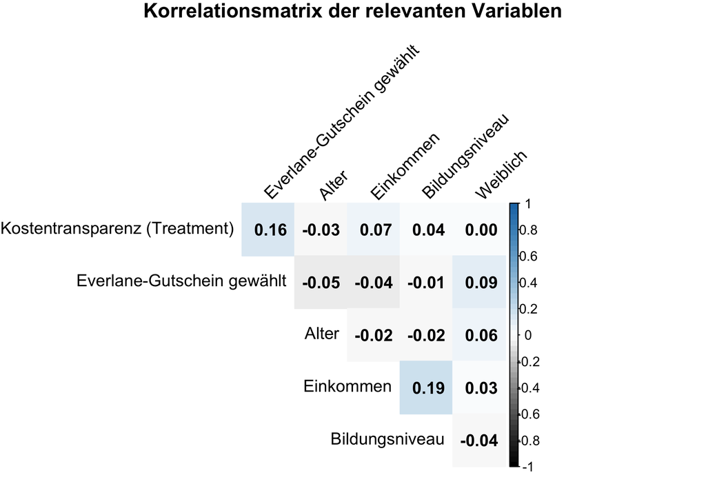

**Beschreibung der Grafik**

Die dargestellte Grafik zeigt eine Korrelationsmatrix in Form eines Dreiecks, in der die paarweisen Zusammenhänge zwischen sechs Variablen abgebildet sind: dem Treatment (Kostentransparenz), der Wahl des Everlane-Gutscheins, dem Alter der Befragten, deren Einkommen, dem Bildungsniveau sowie dem Geschlecht (weiblich). Die Matrix ist farblich codiert, wobei positive Korrelationen blau und negative Korrelationen schwarz dargestellt sind. Die Zahlen innerhalb der Felder geben den exakten Korrelationswert zwischen den jeweiligen Variablen an, wobei nur ein Dreieck ausgefüllt ist, um Redundanzen zu vermeiden und die Lesbarkeit zu verbessern. Neben der Korellation zwischen Treatment und Everlane, was im Folgenden erläutert wird, ist die Korellation von Einkommen - Bildungsniveau mit 0.19 (Ein höheres Einkommen geht grundsätzlich mit höherer Bildung einher), die Korellation von Everlane - Weiblich mit 0.09 (ist in der folgenden Analyse allerdings nicht wichtig) und die Korellation von Treatment - Einkommen von 0.07 bemerkenswert. Die restlichen Korellationen sind so gering, dass diese keine große Rolle spielen.

**Positiver Zusammenhang zwischen Treatment und Everlane**

Im Mittelpunkt der Analyse steht die Korrelation zwischen der Treatment-Variable (also ob eine Person zufällig in die Transparenzbedingung eingeteilt wurde) und der Wahl des Everlane-Gutscheins. Diese beträgt 0.16. Ein positiver, aber schwacher Zusammenhang.  
Im Kontext der Hypothese, dass Kostentransparenz die Entscheidung für Everlane beeinflusst, lässt sich diese Korrelation wie folgt interpretieren: Personen, die der Transparenzbedingung ausgesetzt waren, tendierten mit höherer Wahrscheinlichkeit dazu, sich für einen Everlane-Gutschein zu entscheiden. Ein positiver Zusammenhang bedeutet in diesem Fall, dass ein höherer Wert auf der Treatment-Variable (also Zugehörigkeit zur Transparenzgruppe) mit einem höheren Wert auf der Gutschein-Entscheidung (also Auswahl von Everlane) einhergeht. Dies unterstützt die Hypothese, dass transparente Preisgestaltung einen positiven Einfluss auf Konsumentscheidungen haben kann – möglicherweise, weil sie Vertrauen schafft oder moralisches Verhalten signalisiert.

**Korrelation weist auf Zusammenhang, jedoch nicht auf Kausalität hin**

Auch wenn ein positiver Zusammenhang vorliegt, wie in diesem Fall zwischen Treatment und Gutscheinwahl, ist es methodisch wichtig, zwischen Korrelation und Kausalität zu unterscheiden.  
Eine Korrelation beschreibt lediglich, dass zwei Variablen gemeinsam variieren – sie liefert jedoch keine Information über die Richtung oder Ursache dieses Zusammenhangs. Selbst bei einem randomisierten Treatment, wie hier im Experiment, ist ein Korrelationswert allein nicht ausreichend, um einen kausalen Effekt nachzuweisen. Warum?

- Erstens können Störvariablen oder Zufallseinflüsse den Zusammenhang verzerren. Die Randomisierung hilft, diese Einflüsse im Durchschnitt zu kontrollieren, aber eine reine Korrelation berücksichtigt sie nicht systematisch.
- Zweitens kann eine Korrelation nicht zwischen Ursache und Wirkung unterscheiden. Nur weil zwei Dinge zusammenhängen, bedeutet das nicht, dass das eine das andere verursacht.
- Drittens ist der statistische Beweis für einen kausalen Effekt meist an spezifische Methoden gebunden – etwa Regressionsanalysen, die auch Konfidenzintervalle und Signifikanzniveaus liefern, oder an experimentelle Designs, die Kausalität explizit testen.

Obwohl die Randomisierung hier stark dafür spricht, dass der beobachtete Zusammenhang tatsächlich durch das Treatment verursacht wurde, wäre für einen belastbaren kausalen Schluss eine modellgestützte Auswertung notwendig (z.B. logistische Regression), um alternative Erklärungen auszuschließen und die Größe des Effekts sowie seine Signifikanz zu bestimmen.

**Korrelationsmatrix im Vergelich zum Mittelwert**

Eine Korrelationsmatrix bietet gegenüber einem einfachen Mittelwertvergleich mehrere Vorteile:

- Erstens ermöglicht sie einen ganzheitlichen Überblick über die Beziehungen zwischen allen Variablen – nicht nur zwischen Treatment und Ergebnis, sondern auch zwischen Kontrollvariablen wie Alter, Einkommen, Bildung oder Geschlecht.
- Zweitens kann sie Hinweise darauf geben, ob potenzielle Störfaktoren oder Kovariablen systematisch mit dem Treatment oder der abhängigen Variable zusammenhängen – was für die Interpretation von Mittelwertunterschieden relevant ist.
- Drittens erlaubt sie eine visuelle und intuitive Erfassung von Mustern im Datensatz. Während Mittelwertvergleiche sich immer nur auf zwei Gruppen und eine Zielvariable beziehen, kann die Korrelationsmatrix komplexe Zusammenhänge und Strukturen sichtbar machen.
- Schließlich kann sie dabei helfen, Multikollinearität zu identifizieren – also Situationen, in denen Prädiktoren untereinander stark korrelieren, was bei der Modellbildung problematisch wäre.

In der vorliegenden Analyse sehen wir z.B., dass das Treatment nicht signifikant mit den soziodemografischen Variablen (Alter, Bildung, Einkommen, Geschlecht) korreliert. Das ist ein wichtiger Hinweis, dass die Randomisierung funktioniert hat – was durch einen Mittelwertvergleich nicht so schnell ersichtlich wäre.

7. In Aufgabe 1 und 2 haben Sie gelesen, dass den Teilnehmern ein Angebot gemacht wurde, eine Everlane-Gutscheinkarte anzunehmen. Erzeugen Sie eine geeignete Grafik, die den durchschnittlichen Anteil der angenommenen Angebote (d.h. den Anteil, in dem die Everlane-Karte gewählt wurde) getrennt für die Treatment- und die Kontrollgruppe darstellt. Fügen Sie in der Grafik zusätzlich den Standardfehler der Mittelwerte ein. Führen Sie einen T-Test durch, um zu prüfen, ob der Unterschied im Mittelwert zwischen der Treatment- und Kontrollgruppe statistisch signifikant ist, und geben Sie das Testergebnis (den p-Wert) deutlich sichtbar in der Grafik an. Achten Sie dabei auf eine verständliche Beschriftung Ihrer Grafik sowie auf einen aussagekräftigen Titel.

Beschreiben und interpretieren Sie ihre Grafik. Gehen Sie insbesondere auf folgende Fragen ein:

- Welche Aussage lässt sich auf Basis des durchgeführten T-Tests treffen?
- Welche der in den vorherigen Aufgaben (vgl. Aufgabe 4 und 5) analysierten Faktoren könnten dazu beigetragen haben, dass ein signifikanter Unterschied im Anteil angenommener Everlane-Angebote zwischen Treatment- und Kontrollgruppe beobachtet wird?

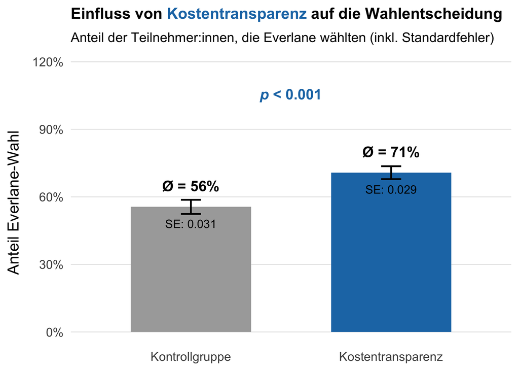

**Beschreibung der Grafik**

Die Grafik stellt den durchschnittlichen Anteil der Teilnehmer:innen, die den Everlane-Gutschein gewählt haben, getrennt nach zwei Gruppen dar:

- Kontrollgruppe (ohne Kostentransparenz)
- Treatmentgruppe (mit Kostentransparenz)

Auf der y-Achse ist der Anteil der angenommenen Angebote (also der Wahl des Everlane-Gutscheins) in Prozent dargestellt. Die Balken zeigen die Mittelwerte dieser Anteile:

- Kontrollgruppe: ca. 56 %
- Treatmentgruppe: ca. 71 %

In jedem Balken sind die Standardfehler der Mittelwerte (SE) als Fehlerbalken (Error Bars) mit Zahlenwerten abgebildet:

- Kontrollgruppe: SE = 0,031
- Treatmentgruppe: SE = 0,029

**Interpretation der Grafik**

Die Grafik zeigt, dass die Treatmentgruppe, die eine Produktseite mit Kostentransparenz gesehen hat, im Durchschnitt einen deutlich höheren Anteil an Everlane-Gutscheinwahlen aufweist (71 %) als die Kontrollgruppe (56 %).  
Der Unterschied von 15 Prozentpunkten ist nicht nur numerisch groß, sondern auch statistisch hoch signifikant (p < 0,001). Das bedeutet:

- Die Wahrscheinlichkeit, dass dieser Unterschied durch Zufall zustande gekommen ist, liegt unter 0,1 %.
- Es besteht sehr starke Evidenz dafür, dass die Kostentransparenz einen positiven Effekt auf die Wahl des Everlane-Gutscheins hat.

**Aussagen zum T-Test**

- Der T-Test vergleicht die Mittelwerte der beiden unabhängigen Gruppen (Treatment vs. Kontrolle) hinsichtlich der Entscheidung für Everlane.
- Der sehr niedrige p-Wert (< 0,001) bestätigt, dass die Differenz der Mittelwerte statistisch signifikant ist.
- Daraus folgt, dass Kostentransparenz als experimentelle Manipulation das Verhalten der Teilnehmer:innen maßgeblich beeinflusst hat: Die Offenlegung der Produktionskosten erhöht die Kaufpräferenz für den transparenten Anbieter.

**Mögliche Faktoren, die zu diesem Unterschied beigetragen haben (bezogen auf Aufgabe 4 und 5)**

Obwohl das Experiment randomisiert war und die Gruppen sich in soziodemografischen Merkmalen (Alter, Geschlecht, Bildung) kaum unterscheiden, gibt es einige wichtige Überlegungen:

- Einkommensunterschied
  - In der Balancing-Tabelle (Aufgabe 5) zeigte sich ein leichter, tendenzieller Unterschied im Einkommen zwischen den Gruppen (p ≈ 0,098), wobei die Treatmentgruppe ein etwas höheres Einkommen aufwies.
  - Höheres Einkommen könnte mit einer höheren Zahlungsbereitschaft oder einem anderen Kaufverhalten korrelieren, was potentiell die Wahl des Everlane-Gutscheins begünstigen könnte.
  - Obwohl der Einkommenseffekt nicht signifikant war, sollte dieser als potenzieller Confounder in der Regressionsanalyse kontrolliert werden, um den Effekt der Kostentransparenz sauber zu isolieren.
- Kontrolle anderer soziodemografischer Variablen
  - Alter, Geschlecht und Bildungsniveau unterschieden sich nicht signifikant zwischen den Gruppen.
  - Dennoch könnten individuelle Unterschiede in diesen Variablen den Effekt auf die Kaufentscheidung moderieren oder beeinflussen (z.B. unterschiedliche Vertrauensvorschuss bei unterschiedlichen Bildungsgraden).
  - Eine weitere Analyse sollte diese Variablen ebenfalls berücksichtigen, um die Wirkung der Kostentransparenz zu präzisieren.
- Qualität der Manipulation (Verständnis)
  - Die Variable passed zeigte, dass etwa 77 % der Teilnehmer den Verständnischeck bestanden haben.
  - Ein nicht korrektes Verständnis der Kostentransparenz könnte die Wirkung abschwächen.
  - Es ist sinnvoll, die Analyse auch auf Teilnehmer zu beschränken, die den Verständnischeck bestanden haben, um Verzerrungen zu vermeiden.
- Anreizkompatibilität (Email-Angabe)
  - Teilnehmer, die eine E-Mail-Adresse angegeben haben (56 %), sind eher motiviert, ernsthafte Entscheidungen zu treffen.
  - Eine Analyse der Effekte auf diese Subgruppe kann die Validität der Ergebnisse weiter stärken.

In den vorherigen Aufgaben des Projekts haben Sie sich bereits intensiv mit dem Experiment 1 auseinandergesetzt, in dem untersucht wurde, ob und wie die Offenlegung von Produktionskosten - also Kostentransparenz - das Konsumverhalten beeinflusst. Es wurde gezeigt: Wenn Konsument:innen transparent mitgeteilt wird, wie sich die Kosten eines Produkts zusammensetzen, steigt ihre Bereitschaft, bei dem entsprechend transparenten Unternehmen einzukaufen.

Diese Ergebnisse legen nahe, dass die Offenlegung sensibler Unternehmensinformationen (wie Produktionskosten) das Vertrauen der Konsument:innen in das Unternehmen stärkt und sie somit eher zu einem Kauf motiviert.

Doch was genau ist der psychologische Mechanismus hinter dieser Wirkung? Ist es tatsächlich das Vertrauen in das Unternehmen, das durch die Offenlegung sensibler Informationen gestärkt wird - und in der Folge die Kaufbereitschaft erhöht?

Um genau diese Frage zu beantworten, führen die Autoren ein weiteres Experiment durch, das den vermuteten psychologischen Vermittlungsmechanismus des Vertrauens genauer untersucht. Dabei wurde geprüft, ob Vertrauen tatsächlich als Mediator zwischen Kostentransparenz und Kaufinteresse wirkt. Hierzu wurde ein kontrolliertes Online-Experiment mit über 600 Teilnehmer:innen durchgeführt. Die Teilnehmenden wurden zufällig einer von zwei Bedingungen zugewiesen:

- In der **Kostentransparenz-Gruppe** (Treatment) wurde zusätzlich eine detaillierte Aufschlüsselung der Produktionskosten angegeben. Diese beinhaltete die einzelnen Kostenkomponenten (z.B. Kakaobutter, Verpackung, Arbeitskosten) sowie die Gesamtkosten der Schokoladentafel (vgl. Abbildung 2 im Anhang).
- In der **Kontrollgruppe** sahen die Teilnehmer die Verpackung einer fiktiven Schokoladenmarke namens „Cocoa Passion“. Diese enthielt nur die üblichen Informationen wie Zutaten, Nährwerte und eine Produktbeschreibung.

Ziel war es, zu untersuchen, ob die Offenlegung dieser sensiblen Informationen das Vertrauen der Konsument:innen in die Marke stärkt - und ob dieses Vertrauen wiederum die Kaufbereitschaft beeinflusst. In den nächsten Aufgaben werden Sie diese Studie genauer beleuchten, analysieren und evaluieren, ob sich die Hypothese empirisch bestätigen lässt.

8. Lesen Sie die Daten des zweiten Experiments (`Experiment2.csv`) in R ein. Nennen Sie den Datensatz `daten_exp2`. Benennen Sie die Variable `cost` in `treatment` um.

Untersuchen Sie, ob sich die Teilnehmer, die die Verpackung mit transparenter Kosteninformation gesehen haben, systematisch von jenen unterscheiden, die nur die Kontrollversion gesehen haben.

Erstellen Sie hierfür eine Balancing-Tabelle, in der Sie die Mittelwerte von Alter (age), Geschlecht (female), Einkommensstufe (income), Bildungsniveau (educ), Vertrauen (trust) und Kaufbereitschaft (wtb) zwischen den beiden Gruppen vergleichen, die Differenzen berechnen und mithilfe von T-Tests prüfen, ob diese Unterschiede statistisch signifikant sind. Nehmen Sie weiterhin die Anzahl an Beobachtungen in der Treatment- und in der Kontrollgruppe in ihre Tabelle mit auf.

Beschreiben und interpretieren Sie ihre Tabelle. Gehen Sie dabei insbesondere auf folgende Fragen ein:

- Was versteht man unter der Variable `wtb`?
- Was lässt sich aus der Größen der Stichprobe ableiten?
- Wo könnte es bei einer Regression (oder einem sonstigen Vergleich der Gruppen) zu Problemen kommen und was wären mögliche Auswirkungen?

*Hinweis:* Für die Beschreibung der `wtb` können Sie das bereitgestellte Readme nutzen.

**Balancing-Tabelle: Vergleich Treatment- vs. Kontrollgruppe (Experiment 2)**

| Variable | Ø Treatment | Ø Kontrolle | Differenz | p-Wert |
| --- | --- | --- | --- | --- |
| Anzahl Beobachtungen | 306.00 | 308.00 | −2.00 |  |
| Alter - [age] | 34.06 | 36.27 | −2.21 | 0.016 |
| Geschlecht (weiblich) - [female] | 0.48 | 0.42 | 0.05 | 0.207 |
| Einkommen - [income] | 6.79 | 6.96 | −0.17 | 0.372 |
| Bildung - [educ] | 3.57 | 3.51 | 0.05 | 0.443 |
| Vertrauen [trust] | 5.27 | 4.82 | 0.45 | 0.000 |
| Kaufbereitschaft - [wtb] | 4.27 | 3.74 | 0.53 | 0.001 |

**Beschreibung und Interpretation der Balancing-Tabelle**

Die Tabelle zeigt für das Experiment 2 die Mittelwerte verschiedener Variablen(“age”, “female”, “income”, “educ”, “trust” und “wtb”) und zusätzlich die Anzahl der Beobachtungen, getrennt für die Treatment-Gruppe (Kostentransparenz) und die Kontrollgruppe (ohne Kostentransparenz), deren Differenzen sowie die Ergebnisse von T-Tests, mit denen geprüft wird, ob die Mittelwertunterschiede statistisch signifikant sind.

- Stichprobengröße (Anzahl Beobachtungen): Die Treatment-Gruppe umfasst 306 Personen, die Kontrollgruppe 308 Personen. Die Gruppengrößen sind somit fast gleich groß, was für die Vergleichbarkeit der Gruppen ideal ist.  
  Interpretation: Eine fast gleich große Verteilung der Teilnehmer auf die beiden Gruppen spricht dafür, dass die Randomisierung gut funktioniert hat und die beiden Gruppen hinsichtlich der Stichprobengröße vergleichbar sind. Dadurch werden Verzerrungen durch Gruppengrößenunterschiede minimiert, und die statistische Power für Gruppenvergleiche ist optimal.
- Altersvergleich (Alter): Der Mittelwert liegt bei 34,06 Jahren in der Treatment-Gruppe und bei 36,27 Jahren in der Kontrollgruppe. Die Differenz von -2,21 Jahren ist mit einem p-Wert von 0,016 signifikant (typischerweise unter 0,05).  
  Interpretation: Die Treatment-Gruppe ist im Durchschnitt etwas jünger als die Kontrollgruppe. Da Alter Einfluss auf das Konsumverhalten und auch auf Vertrauen oder Kaufbereitschaft haben kann, stellt dieser Unterschied eine potenzielle Störgröße dar. Bei Regressionsanalysen sollte das Alter daher als Kontrollvariable berücksichtigt werden, um diesen Unterschied zu kontrollieren.
- Geschlecht (weiblich): Die Anteile weiblicher Teilnehmer sind mit 48 % (Treatment) und 42 % (Kontrolle) ähnlich, die Differenz ist nicht signifikant (p = 0,207).  
  Interpretation: Es gibt keine statistisch signifikanten Unterschiede im Geschlechterverhältnis zwischen den Gruppen, wodurch Geschlecht als potenzieller Confounder weniger kritisch erscheint. Dennoch sollte es bei weiterführenden Analysen berücksichtigt werden.
- Einkommen: Die mittlere Einkommensstufe liegt bei 6,79 (Treatment) vs. 6,96 (Kontrolle), die Differenz ist nicht signifikant (p = 0,372).  
  Interpretation: Einkommensniveau unterscheidet sich nicht systematisch zwischen den Gruppen. Das spricht für ein gutes Balancing bei diesen soziodemographischen Variablen.
- Bildung: Mittelwerte sind 3,57 vs. 3,51, ebenfalls ohne signifikanten Unterschied (p = 0,443).  
  Interpretation: Bildungsniveau unterscheidet sich nicht systematisch zwischen den Gruppen. Das spricht für ein gutes Balancing bei diesen soziodemographischen Variablen.
- Vertrauen: Im Treatment liegt der Mittelwert bei 5,27, in der Kontrollgruppe bei 4,82. Die Differenz von 0,45 ist hochsignifikant (p < 0,001).  
  Interpretation: wird Zusätzlich bei Kaufbereitschaft erwähnt.
- Kaufbereitschaft (wtb): Die Treatment-Gruppe zeigt mit 4,27 eine deutlich höhere Kaufbereitschaft als die Kontrollgruppe mit 3,74 (Differenz 0,53, p = 0,001).  
  Interpretation: Diese Ergebnisse(Vertrauen und Kaufbereitschaft) bestätigen den vermuteten Effekt der Kostentransparenz: Teilnehmer:innen, die die transparenten Kosteninformationen gesehen haben, vertrauen der Marke mehr und zeigen eine höhere Bereitschaft zum Kauf. Da Vertrauen als potenzieller Mediator angenommen wird, ist das ein wichtiger Befund für die weitere Analyse.

**Variablenbeschreibung wtb:**

- Typ: Ordinal skalierte Variable (1–7)
- Skalierung:
  - 1 = Überhaupt nicht wahrscheinlich
  - 2 = Sehr unwahrscheinlich
  - 3 = Unwahrscheinlich
  - 4 = Teils/teils
  - 5 = Wahrscheinlich
  - 6 = Sehr wahrscheinlich
  - 7 = Extrem wahrscheinlich
- Bedeutung: Selbst eingeschätzte Kaufbereitschaft der Teilnehmer:innen für das im Experiment präsentierte Produkt („Cocoa Passion“-Schokolade). Die Variable erfasst also, wie stark das individuelle Kaufinteresse ausfällt.
- Rolle im Experiment: Die Variable bildet das Verhaltensergebnis (Outcome) ab, das durch die Intervention (Kostentransparenz vs. Kontrollbedingung) beeinflusst werden soll. Sie dient somit als zentrale Zielgröße, um zu untersuchen, ob Teilnehmer:innen durch die zusätzliche Offenlegung der Produktionskosten eher bereit sind, das Produkt zu kaufen.
- Funktion in der Auswertung: Als abhängige Variable in Gruppenvergleichen und Regressionsanalysen, um den Effekt der Kostentransparenz auf die Kaufneigung zu messen. Und als Endpunkt in einer Mediationsanalyse, bei der geprüft wird, ob Vertrauen (trust) als vermittelnder Mechanismus (Mediator) zwischen Transparenz und Kaufbereitschaft wirkt.

**Was lässt sich aus den Größen der Stichprobe ableiten?**

- Die Stichprobe ist mit insgesamt 614 Teilnehmer:innen (306 Treatment, 308 Kontrolle) groß genug, um statistisch valide Aussagen treffen zu können. Die nahezu gleiche Gruppengröße stellt sicher, dass die Ergebnisse nicht durch ungleiche Stichprobenverteilungen verzerrt werden.
- Eine ausreichend große Stichprobe erhöht die Power, also die Wahrscheinlichkeit, tatsächlich existierende Effekte zu entdecken.
- Die Randomisierung scheint grundsätzlich gut funktioniert zu haben, da keine systematischen Unterschiede in den meisten demographischen Variablen (außer Alter) bestehen.
- Genaue Details zu den weiteren Größen wurden bereits in der Interpretation gegeben. So sind die Variablen Alter, Vertrauen und Kaufbereitschaft die wichtigsten Auffälligkeiten unter dieser Darstellung.

**Wo könnte es bei einer Regression (oder einem sonstigen Vergleich der Gruppen) zu Problemen kommen und was wären mögliche Auswirkungen?**

- Problem durch Altersunterschied: Der signifikante Altersunterschied zwischen den Gruppen kann als Confounder wirken. Wenn das Alter mit Vertrauen, Kaufbereitschaft oder anderen interessierenden Variablen zusammenhängt, können Unterschiede in der Outcome-Variable (z. B. Kaufbereitschaft) nicht ausschließlich auf den Treatment-Effekt zurückgeführt werden.  
  Auswirkung: Ohne Kontrolle für Alter könnte der geschätzte Effekt der Kostentransparenz verzerrt sein (Bias). Das Alter sollte daher in jeder multivariaten Analyse als Kontrollvariable einbezogen werden, um den kausalen Effekt der Behandlung korrekt zu identifizieren.
- Mögliche weitere Confounder:  
  Obwohl Geschlecht, Einkommen und Bildung keine signifikanten Unterschiede zeigen, können sie dennoch als Kontrollvariablen in der Regression berücksichtigt werden, um mögliche subtile Effekte auszuschließen.
- Effekt auf Mediationsanalyse:  
  Da Vertrauen als Mediator untersucht wird, ist es wichtig, dass auch die Kovariaten wie Alter mit einbezogen werden, da diese Einfluss auf das Vertrauen und die Kaufbereitschaft haben könnten. Andernfalls könnte die Mediationsanalyse verfälscht sein.
9. In ihrem Datensatz gibt es einige Beobachtungen ohne vorhandene Werte. Behalten Sie nur die Beobachtungen bei denen vollständige Werte vorliegen. Erzeugen Sie eine geeignete Grafik, welche den durchschnittlichen Anteil der ‘Kaufbereitschaft’ im zweiten Experiment für die Treatment- und Kontrollgruppe darstellt.

Die Grafik soll:

- die Mittelwerte der Kaufbereitschaft für beide Gruppen zeigen,
- die zugehörigen Standardfehler als Fehlerbalken visualisieren und
- das Ergebnis des T-Tests, der die Mittelwertdifferenz prüft, direkt in die Grafik integrieren.

Beschreiben und interpretieren Sie ihre Grafik.

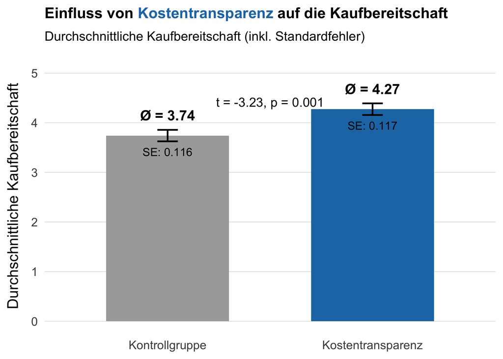

**Beschreibung der Grafik:**

Die Grafik trägt den Titel „Einfluss von Kostentransparenz auf die Kaufbereitschaft“ und zeigt einen Balkendiagrammvergleich zweier Gruppen: Kontrollgruppe und Kostentransparenz-Gruppe (Treatment-Gruppe). Sie visualisiert die durchschnittliche Kaufbereitschaft (inkl. Standardfehler) der Teilnehmer:innen im Rahmen von Experiment 2. Die Y-Achse ist beschriftet mit „Durchschnittliche Kaufbereitschaft“ und reicht von 0 bis 5. Es handelt sich um eine Skala mit kontinuierlichen Werten, basierend auf der 7-Punkte-Likert-Skala der Variable wtb (1 = überhaupt nicht wahrscheinlich, 7 = extrem wahrscheinlich). Die X-Achse zeigt zwei Balken, links die graue Kontrollgruppe und rechts die blaue Kostentransparenz.Die Kontrollgruppe besitzt einen Mittelwert von 3.74 und einen Standardfehler von 0.116, visualisiert mit einem Fehlerbalken. Die Kostentransparenzgruppe besitzt einen Mittelwert von 4.27 und einen Standardfehler von 0.117, visualisiert mit einem Fehlerbalken. Die unterschiedlichen Mittelwerte kann man anhand der Höhe der Balken ablesen. Der blaue Balken der Kostentransparenz ist dementsprechend etwas größer. Zwischen den beiden Balken ist das Ergebnis eines t-Tests angegeben mit t= -3.23 und p = 0.001. Das deutet auf einen signifikanten Mittelwertsunterschied zwischen den beiden Gruppen hin.

**Interpretation der Grafik:**

Die Grafik stellt klar dar, wie sich die Kostentransparenz auf die Kaufbereitschaft der Konsument:innen im Rahmen von Experiment 2 auswirkt.  
Die durchschnittliche Kaufbereitschaft liegt in der Kontrollgruppe bei 3.74, während sie in der Kostentransparenz-Gruppe bei 4.27 liegt. Dies entspricht einer Erhöhung von etwa 0.53 Punkten auf der 7-stufigen Skala – ein beachtlicher Effekt, wenn man bedenkt, dass es sich um eine rein psychologische Intervention (Transparenz über Produktionskosten) handelt. Dies bedeutet, dass Teilnehmende, die eine detaillierte Aufschlüsselung der Produktionskosten sahen, deutlich eher bereit waren, das Produkt zu kaufen. Diese erhöhte Kaufbereitschaft spricht dafür, dass Kostentransparenz ein effektiver Hebel zur Beeinflussung von Konsumentenverhalten ist.  
Der in der Grafik angegebene t-Wert von -3.23 und p-Wert von 0.001 weisen auf eine hoch signifikante Differenz zwischen den Gruppen hin (bei einem üblichen Signifikanzniveau von p < .05). Das heißt: Die Wahrscheinlichkeit, dass dieser Unterschied rein zufällig entstanden ist, ist extrem gering.  
Der negative t-Wert ergibt sich daraus, dass die Kontrollgruppe als Referenzgruppe verwendet wurde – und deren Mittelwert niedriger ist als der der Transparenzgruppe.  
Beide Gruppen weisen einen sehr ähnlichen Standardfehler auf (ca. ±0.116). Die Fehlerbalken überlappen sich nicht nennenswert, was die Signifikanz der beobachteten Unterschiede zusätzlich stützt. Die Streuung in den Antworten war also relativ gleichmäßig, und die Mittelwertunterschiede sind robust gegenüber zufälligen Schwankungen. Diese Ergebnisse stützen die übergeordnete Annahme des Projekts: Transparente Kommunikation von Unternehmensinformationen stärkt die Bereitschaft von Konsument:innen, einem Anbieter zu vertrauen und von ihm zu kaufen. Dies legt nahe, dass Kostentransparenz ein zentrales Mittel zur Vertrauensbildung im Konsumkontext darstellt.

Nachdem Sie nun die Differenzen in der Kaufabsicht zwischen der Treatment- und der Kontrollgruppe im zweiten Experiment überprüft und getestet haben, geht es im nächsten Schritt darum, den möglichen Mediator Vertrauen genauer zu untersuchen. Hierfür sollen Sie sich in einem ersten Schritt das Vertrauen der Personen allgemein anschauen, um einen Eindruck zu dieser wichtigen Variable zu bekommen. Dafür werden Personen anhand **hohem und niedrigem** Vertrauen und deren Kaufbereitschaft für das Produkt unterteilt.

10. Erstellen Sie eine oder mehrere geeignete Grafik(en), die den Zusammenhang zwischen Vertrauen (Trust) und der Kaufabsicht (WTB) **unabhängig** der beiden Treatment- und Kontrollgruppen darstellen. Achten Sie auf eine passende Darstellung der Informationen.

Die Grafik(en) sollen folgende Informationen enthalten:

- Unterteilen Sie ihre Daten in Personen mit `hohem` und `niedrigem` Vertrauen. Nutzen Sie für die Unterteilung den Median des Vertrauens in ihren Daten als Schwellenwert.
- Abhängig der Einstufungen in `hohes` und `niedriges` Vertrauen soll nun die durchschnittliche Kaufbereitschaft dargestellt werden. Hier soll die Grafik so dargestellt werden, dass auf der x-Achse das Vertrauensniveau (“hoch” und “niedrig”) und auf der y-Achse die entsprechende Kaufbereitschaft abgebildet wird.
- Berechnen Sie weiterhin die Mittelwerte der beiden Vertrauensgruppen und visualisieren diese in geeigneter Art und Weise in ihren Grafik(en).
- Führen Sie einen t-Test durch, um zu prüfen, ob die Mittelwertsunterschiede zwischen den beiden Vertrauensgruppen statistisch signifikant sind. Geben Sie den p-Wert in der Grafik an.

Beschreiben und interpretieren Sie ihre Grafik(en). Beantworten Sie insbesondere folgende Fragen:

- Welche Implikationen hat ein signifikanter Unterschied für die Rolle von Vertrauen auf Kaufentscheidungen?
- Wie stark unterscheidet sich die Kaufbereitschaft zwischen Personen mit hohem und niedrigem Vertrauen?
- Könnte auf Basis ihrer Darstellung Vertrauen als Mediator zwischen dem Treatment und der Kaufbereitschaft fungieren?

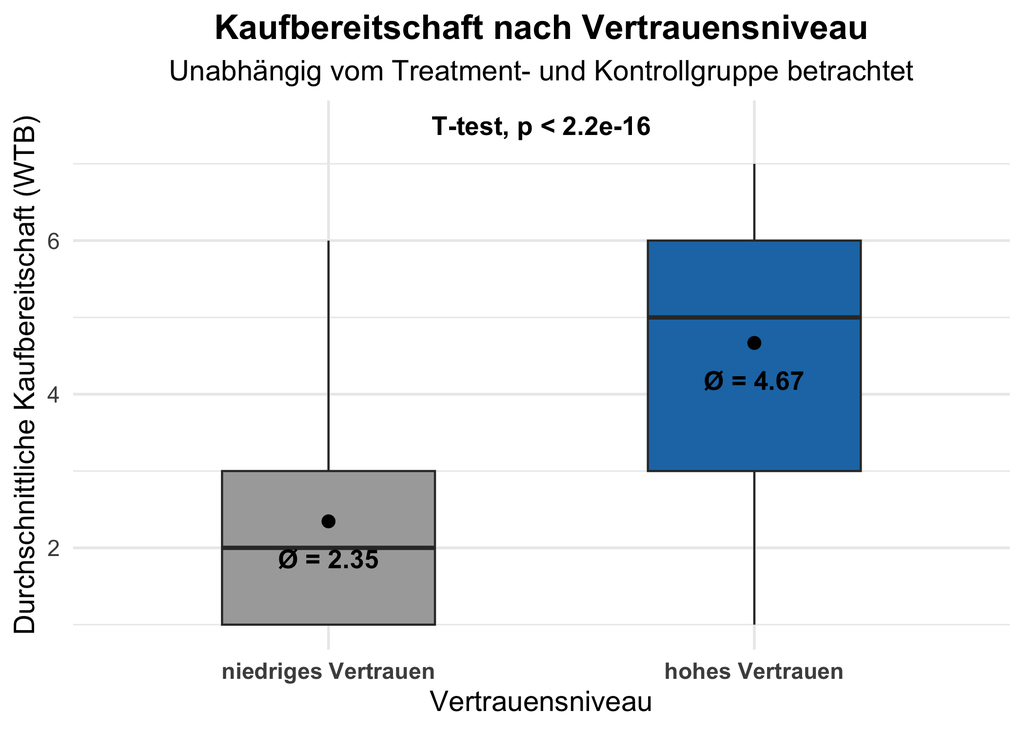

**Beschreibung und Interpretation der Grafik**

**Implikationen eines signifikanten Unterschieds für die Rolle von Vertrauen auf Kaufentscheidungen**

Ein signifikanter Unterschied in der Kaufbereitschaft (WTB) zwischen Personen mit hohem Vertrauen (Ø = 4.67) und niedrigem Vertrauen (Ø = 2.35) deutet stark darauf hin, dass Vertrauen ein zentraler psychologischer Prädiktor für Kaufentscheidungen ist.  
Der in der Grafik angegebene p-Wert < 0.000 (bzw. < .001) zeigt, dass dieser Unterschied hochsignifikant ist – also mit sehr hoher Wahrscheinlichkeit nicht zufällig auftritt. Das bedeutet:

- Vertrauen beeinflusst direkt die Bereitschaft, ein Produkt zu kaufen.
- Konsument:innen, die dem Anbieter bzw. dem Produkt mehr Vertrauen entgegenbringen, zeigen eine deutlich gesteigerte Kaufabsicht.
- Vertrauen als psychologischer Mechanismus: Da der Unterschied so deutlich und signifikant ausfällt, ist Vertrauen kein „nice-to-have“, sondern eine wesentliche psychologische Grundlage, die Konsument:innen dazu bringt, sich für ein Produkt zu entscheiden.

Implikation: Unternehmen, die Vertrauen aktiv fördern (z.B. durch Transparenz, soziale Verantwortung, Kundenservice), können so ihre Absatzchancen signifikant steigern. Vertrauen ist also kein “weicher” Faktor, sondern ein entscheidender ökonomischer Hebel.

**Unterscheidung der Kaufbereitschaft zwischen Personen mit hohem und niedrigem Vertrauen**

Der Unterschied ist deutlich und substantiell:

- Personen mit niedrigem Vertrauen: durchschnittliche Kaufbereitschaft von 2.35
- Personen mit hohem Vertrauen: durchschnittliche Kaufbereitschaft von 4.67

Das entspricht einer Differenz von 2.32 Punkten auf der 7-stufigen Likert-Skala – was über ein Drittel der gesamten Skala ausmacht. In psychologischen Studien gilt eine Differenz von mehr als einem Skalenpunkt bereits als groß. Eine Differenz von über zwei Punkten ist außergewöhnlich deutlich. Das bedeutet konkret:

- Personen mit hohem Vertrauen bewerten ihre Kaufabsicht fast doppelt so hoch wie jene mit niedrigem Vertrauen.
- Es handelt sich nicht nur um einen statistisch signifikanten, sondern auch praktisch hochrelevanten Effekt.

Zusammengefasst: Vertrauen ist einer der stärksten Einflussfaktoren auf die Kaufabsicht in deinem Datensatz.

**Vertrauen als Mediator zwischen dem Treatment und der Kaufbereitschaft**

Basierend auf den dargestellten Ergebnissen ist es sehr gut möglich, dass Vertrauen als Mediator zwischen Kostentransparenz (Treatment) und Kaufbereitschaft fungiert. Die Gründe:

- Voraussetzungen für Mediation: Für eine Mediationsanalyse muss gezeigt werden, dass das Treatment (Kostentransparenz) die Mediatorvariable (Vertrauen) beeinflusst und dass die Mediatorvariable wiederum die Zielvariable (Kaufbereitschaft) beeinflusst.
- Aus Experiment 1 wissen wir, dass Kostentransparenz die Kaufbereitschaft erhöht.
- Die jetzige Grafik und Analyse zeigen, dass Vertrauen stark mit der Kaufbereitschaft zusammenhängt (deutlicher Unterschied zwischen hohem und niedrigem Vertrauen).
- Wenn in einer weiteren Analyse oder in deinem Datensatz Kostentransparenz auch die Variable Vertrauen signifikant erhöht, spricht das für eine vermittelnde Wirkung von Vertrauen.

Daraus folgt:

- Vertrauen kann der psychologische Mechanismus sein, über den Kostentransparenz die Kaufbereitschaft steigert.
- Offenlegung sensibler Informationen wie Produktionskosten baut Vertrauen auf, welches dann die Kaufabsicht stärkt.
- Der große Unterschied in der Kaufbereitschaft zwischen hohem und niedrigem Vertrauen unterstützt diese Annahme, da es zeigt, dass ohne Vertrauen der positive Effekt von Kostentransparenz womöglich abgeschwächt wird.

# Regressionsanalyse

Sie haben nun ihren Datensatz kennengelernt und es scheint so, als ob insbesondere Personen, welche transparente Kosten sehen, dazu neigen, das Produkt zu kaufen. Doch um ihre deskriptiven Analysen zu erhärten, wollen Sie im folgenden eine Analyse mittels Regressionen durchführen.

11. Betrachten Sie hier noch einmal das erste Experiment (`daten_exp1`). Führen Sie eine Regression durch, bei der Ihnen `everlane` als abhängige Variable dient. Als erklärende Variable nutzen Sie das `treatment`. Erstellen sie eine weitere Regression, die zusätzlich noch für die folgenden Variablen kontrolliert:
- Alter
- Bildungsstufe
- Einkommen
- Geschlecht

Stellen Sie die Regressionsergebnisse in einer Tabelle mit stargazer oder modelsummary dar!

Beschreiben und interpretieren Sie ihre Ergebnisse. Gehen Sie insbesondere auf folgende Fragen ein:

- Lässt sich der Effekt des Treatments auf die Entscheidung der Kunden kausal interpretieren?
- Ist es wichtig auf weitere Faktoren zu kontrollieren?
- Beziehen Sie sich hier auch auf die Ergebnisse aus Aufgabe 5.

**Lineare Regressionsergebnisse für die Everlane-Wahl**

Abhängige Variable: Everlane-Wahl

| Variable | Nur Treatment (SE) | Mit Kontrollvariablen (SE) |
| --- | --- | --- |
| Intercept | 0.556 (0.030)*** | 0.686 (0.132)*** |
| Kostentransparenz (Treatment) | 0.152 (0.042)*** | 0.155 (0.042)*** |
| Alter | NA | -0.002 (0.002) |
| Einkommen | NA | -0.012 (0.009) |
| Bildungsniveau | NA | -0.001 (0.026) |
| Geschlecht: weiblich | NA | 0.091 (0.042)* |
| R² | 0.025 | 0.039 |
| Adj. R² | 0.023 | 0.030 |
| F-Statistik | 12.80 (df = 1, 503) | 4.07 (df = 5, 499) |
| AIC | 690.06 | 690.55 |
| BIC | 702.73 | 720.12 |
| Beobachtungen | 505 | 505 |

*Signifikanz: *** p < 0.001, ** p < 0.01, * p < 0.05*

**Beschreibung der Tabelle:**

Die vorliegende Tabelle präsentiert die Ergebnisse einer linearen Regression, die den Einfluss von Kostentransparenz (Treatment) auf die Everlane-Wahl untersucht. Zwei Modelle werden verglichen: eines nur mit dem Treatment und eines, das zusätzlich demografische Kontrollvariablen einbezieht.

**Beschreibung und Interpretation der Ergebnisse:**

Die Tabelle zeigt zwei Hauptspalten mit Regressionskoeffizienten und deren Standardfehlern (in Klammern): “Nur Treatment (SE)” und “Mit Kontrollvariablen (SE)”.

- Koeffizient für Kostentransparenz (Treatment):  
  Nur Treatment (SE): Der Koeffizient beträgt 0.152 und ist hochsignifikant (p<0.001). Dies bedeutet, dass die Kostentransparenz einen statistisch bedeutsamen positiven Effekt auf die Everlane-Wahl hat.  
  Mit Kontrollvariablen (SE): Der Koeffizient bleibt mit 0.155 ebenfalls hochsignifikant (p<0.001) und ist nur geringfügig höher als im ersten Modell. Dies deutet darauf hin, dass der positive Effekt der Kostentransparenz auf die Everlane-Wahl robust ist und nicht primär durch die demografischen Merkmale erklärt wird. Konkret bedeutet dies, dass Teilnehmer, die der Bedingung der Kostentransparenz ausgesetzt waren, eine um etwa 0.155 Einheiten höhere Wahrscheinlichkeit oder Tendenz zur Wahl von Everlane aufweisen.
- Koeffizienten der Kontrollvariablen: Alter, Einkommen, Bildungsniveau: Keiner dieser Koeffizienten ist statistisch signifikant (p>0.05). Das bedeutet, dass in diesem Modell diese demografischen Merkmale keinen statistisch bedeutsamen Beitrag zur Erklärung der Everlane-Wahl leisten.  
  Geschlecht: weiblich: Der Koeffizient beträgt 0.091 und ist signifikant (p<0.05, markiert mit *). Dies deutet darauf hin, dass weibliche Teilnehmer eine signifikant höhere Tendenz zur Wahl von Everlane haben als männliche Teilnehmer, selbst nach Kontrolle für Kostentransparenz, Alter, Einkommen und Bildungsniveau.
- Modellstatistiken:  
  R²: Steigt von 0.025 im ersten Modell auf 0.039 im zweiten Modell. Dies bedeutet, dass das Modell mit Kontrollvariablen etwas mehr Varianz in der Everlane-Wahl erklärt (3.9% gegenüber 2.5%).  
  Adj. R²: Zeigt einen ähnlichen Trend (von 0.023 auf 0.030), was darauf hindeutet, dass die zusätzlichen Variablen einen inkrementellen, wenn auch kleinen, Erklärungsbeitrag leisten.  
  F-Statistik: Beide Modelle sind insgesamt statistisch signifikant (hohe F-Werte und niedrige p-Werte), was bedeutet, dass die unabhängigen Variablen gemeinsam einen signifikanten Einfluss auf die abhängige Variable haben.  
  AIC/BIC: Die Werte sind in beiden Modellen relativ nah beieinander. Das zweite Modell hat etwas höhere AIC- und BIC-Werte (690.55/720.12 vs. 690.06/702.73), was unter Berücksichtigung der zusätzlichen Parameter auf eine leichte Komplexitätserhöhung hindeutet.  
  Der Anstieg des R² ist hier wichtiger.

**Kausale Interpretation des Treatment-Effekts:**

Ja, der Effekt des Treatments (Kostentransparenz) auf die Entscheidung der Kunden kann in diesem Kontext kausal interpretiert werden.  
In Aufgabe 5 wurde detailliert dargelegt, dass die Randomisierung in Ihrem Experiment gut gelungen ist. Die p-Werte der T-Tests für Alter, Geschlecht und Bildung waren hoch (deutlich über 0.05), was bedeutet, dass es keine statistisch signifikanten Unterschiede zwischen der Treatment- und Kontrollgruppe in diesen demografischen Merkmalen gab. Obwohl beim Einkommen eine leichte Tendenz zu einem Unterschied bestand (p≈0.098), ist dieser formal nicht signifikant.  
Diese gelungene Randomisierung ist die Grundlage für kausale Schlussfolgerungen. Sie stellt sicher, dass die Treatment- und Kontrollgruppe zu Beginn des Experiments durchschnittlich gleich sind, außer in Bezug auf die Kostentransparenz. Daher können beobachtete Unterschiede in der Everlane-Wahl direkt auf das Treatment zurückgeführt werden. Der signifikante und robuste Koeffizient von 0.155 für “Kostentransparenz (Treatment)” bestätigt diesen kausalen Zusammenhang.

**Bedeutung der Kontrolle auf weitere Faktoren**

Ja, es ist wichtig, auf weitere Faktoren zu kontrollieren, auch wenn einige Kontrollvariablen selbst keinen signifikanten Effekt zeigen.

- Reduzierung von Störfaktoren: Obwohl die Randomisierung in Aufgabe 5 für Alter, Geschlecht und Bildung erfolgreich war, können diese Variablen, auch wenn sie nicht signifikant unterschiedlich zwischen den Gruppen sind, das Konsumentenverhalten beeinflussen. Ihre Aufnahme in das Modell erhöht die Präzision der Schätzung des Treatment-Effekts, indem sie deren Varianz aus der abhängigen Variable “herausrechnen”.
- Umgang mit tendenziellen Unterschieden: Wie in Aufgabe 5 erwähnt, zeigte das Einkommen eine tendenzielle, wenn auch nicht formal signifikante, Differenz zwischen den Gruppen (p≈0.098). Die Kontrolle für Einkommen im zweiten Modell stellt sicher, dass ein eventueller Einfluss des Einkommens auf die Everlane-Wahl nicht fälschlicherweise dem Treatment zugeschrieben wird.
- Identifikation weiterer relevanter Effekte: Das aktuelle Ergebnis zeigt, dass “Geschlecht: weiblich” einen signifikanten Effekt auf die Everlane-Wahl hat (p<0.05). Ohne die Kontrolle dieser Variable hätte man diesen eigenständigen Einfluss nicht identifizieren können. Dies liefert zusätzliche wertvolle Erkenntnisse über die Faktoren, die die Kaufentscheidung beeinflussen.
- Robustheit und Glaubwürdigkeit: Die Tatsache, dass der Treatment-Effekt (0.152 im unkontrollierten Modell vs. 0.155 im kontrollierten Modell) auch nach der Aufnahme von Kontrollvariablen konstant und hochsignifikant bleibt, erhöht die Glaubwürdigkeit und Robustheit Ihrer Ergebnisse. Es zeigt, dass der Effekt der Kostentransparenz nicht durch die untersuchten demografischen Merkmale verzerrt wird.

Zusammenfassend lässt sich sagen, dass die Kontrolle für weitere Faktoren, selbst wenn sie in der Randomisierungsprüfung nicht signifikant ungleich verteilt waren, zur Präzision, Robustheit und einem umfassenderen Verständnis der zugrunde liegenden Mechanismen beiträgt.

Während die bisherigen Analysen zeigen, dass das Treatment einen Effekt hat, stellt sich nun die Frage, warum das so ist. Nun sollten Sie im weiteren Verlauf durch vertiefende Regressionsanalysen prüfen, ob dies auf das Vertrauen der Kunden zurückzuführen ist. Dazu betrachten Sie noch einmal den Datensatz zu Experiment 2 (`daten_exp2`) und untersuchen, ob das Treatment (Kunden sehen transparente Kostenstruktur) zu einer höheren Kaufabsicht führt, weil sie das Vertrauen der Konsumenten in das Unternehmen stärkt.

12. Schauen Sie sich den Einfluss der Kostentransparenz auf die Kaufabsicht in den folgenden zwei Regressionen genauer an und zeigen Sie ihre Ergebnisse nebeneinander:

**1. Regression:** Abhängige Variable ist die Kaufabsicht; die erklärende Variable ist das Treatment.

**2. Regression:** Wie in der 1. Regression, doch kontrollieren Sie hier zusätzlich auf die Variablen Alter, Einkommensniveau, Bildungsstufe und Geschlecht.

Stellen Sie die Regressionsergebnisse in einer Tabelle mit stargazer oder modelsummary dar!

Beschreiben und interpretieren Sie ihre Ergebnisse allgemein. Gehen Sie weiterhin auch speziell auf folgende Fragen ein:

- Sollten die Kontrollvariablen in ihrer zweiten Regression den Koeffizienten des Treatments ändern? Was würden Sie erwarten und warum? Nutzen Sie hierzu die Ergebnisse aus Aufgabe 8.
  - Vergleichen Sie die Regressionskoeffizienten der Treatment-Variable in der ersten und zweiten Regression. Gibt es hier einen signifikanten Unterschied in der Größe des Effekts?
- Bringt ihnen die Regression Vorteile gegenüber einer reinen Darstellung der Mittelwerte wie in Aufgabe 9?
- Ist der Effekt des Treatments auf die Kaufabsicht ihrer Ansicht nach kausal interpretierbar?
  - Welche Voraussetzungen müssen erfüllt sein, damit man diesen Regressionskoeffizienten als kausalen Effekt interpretieren kann?
  - Überlegen Sie sich, wie sich das Ergebnis verändern würde, wenn zusätzlich Vertrauen (trust) in das Modell aufgenommen wird. Würde sich der Effekt von `treatment` verändern? Warum oder warum nicht?

**Regressionsergebnisse: Einfluss von Kostentransparenz auf Kaufabsicht**

| Variable | Nur Treatment (SE) | Mit Kontrollvariablen (SE) |
| --- | --- | --- |
| Intercept | 3.741 (0.116)*** | 3.702 (0.470)*** |
| Kostentransparenz (Treatment) | 0.532 (0.165)** | 0.501 (0.166)** |
| Alter | NA | -0.013 (0.007) |
| Einkommen | NA | 0.023 (0.036) |
| Bildungsniveau | NA | 0.102 (0.099) |
| Geschlecht: weiblich | NA | -0.001 (0.168) |
| R² | 0.017 | 0.025 |
| Adj. R² | 0.015 | 0.016 |
| F-Statistik | 10.43 (df = 1, 599) | 3.01 (df = 5, 595) |
| AIC | 2554.98 | 2558.35 |
| BIC | 2568.18 | 2589.14 |
| Beobachtungen | 601 | 601 |

*Signifikanz: *** p < 0.001, ** p < 0.01, * p < 0.05*

**Beschreibung der Ergebnisse**

In Modell 1 wurde die Kaufabsicht („wtb“) nur als Funktion der Kostentransparenz (Treatment) geschätzt. Der geschätzte Intercept liegt bei 3.741 (SE = 0.116) und ist hochsignifikant. Der Koeffizient für das Treatment beträgt 0.532 (SE = 0.165) und ist signifikant auf dem 1%-Niveau, was darauf hindeutet, dass Teilnehmer:innen im Treatment eine höhere Kaufabsicht angeben als in der Kontrollgruppe.  
Modell 2 erweitert diese Regression um die Kontrollvariablen Alter, Einkommen, Bildungsniveau und Geschlecht. Der Intercept fällt leicht auf 3.702 (SE = 0.470), bleibt aber hochsignifikant. Der Treatment-Koeffizient beträgt nun 0.501 (SE = 0.166) und bleibt signifikant. Die Kontrollvariablen selbst sind größtenteils nicht signifikant, wobei Alter mit einem negativen, aber nicht signifikanten Effekt (-0.013) am ehesten hervortritt.  
Die Gütemaße zeigen, dass das Hinzufügen der Kontrollvariablen zu einem moderaten Anstieg des R² von 0.017 auf 0.025 führt, wobei das bereinigte R² von 0.015 auf 0.016 steigt. Die F-Statistik ist für Modell 1 mit 10.43 signifikant, für Modell 2 mit 3.01 nur noch schwach signifikant. AIC und BIC steigen leicht im komplexeren Modell.

**Interpretation der Ergebnisse**

Der signifikante und positive Koeffizient des Treatments in beiden Modellen bestätigt, dass Kostentransparenz die Kaufabsicht der Teilnehmer:innen erhöht. Die Kontrolle weiterer Variablen verändert den Effekt des Treatments kaum, was darauf hinweist, dass die Randomisierung gut funktioniert hat und die Kontrollvariablen keinen großen Einfluss auf das Ergebnis ausüben. Das Alter zeigt einen leicht negativen Einfluss auf die Kaufabsicht, der jedoch statistisch nicht abgesichert ist.  
Die geringe Steigerung der erklärten Varianz bei Aufnahme der Kontrollvariablen spricht dafür, dass diese Variablen nur wenig zusätzliche Erklärungskraft besitzen. Die vergleichbare Signifikanz des Treatments in beiden Modellen und der kaum veränderte Koeffizient deuten darauf hin, dass die Kostentransparenz ein stabiler Einflussfaktor ist.  
Die Regression bietet gegenüber einfachen Mittelwertvergleichen den Vorteil, dass sie Störgrößen statistisch kontrollieren kann und so einen robusteren Einblick in den Einfluss des Treatments ermöglicht.  
Unter der Annahme, dass die Randomisierung korrekt durchgeführt wurde und keine wesentlichen Confounder fehlen, kann der geschätzte Treatment-Effekt als kausal interpretiert werden. Sollte Vertrauen als vermittelnde Variable in die Analyse aufgenommen werden, wäre zu erwarten, dass der direkte Effekt des Treatments auf die Kaufabsicht abnimmt, da ein Teil des Effekts indirekt über das Vertrauen vermittelt wird.

**Sollten die Kontrollvariablen den Koeffizienten des Treatments verändern?**

In Aufgabe 8 wurde anhand der Balancing-Tabelle gezeigt, dass die Treatment- und Kontrollgruppen in den meisten demografischen Variablen gut vergleichbar sind. Die Gruppengrößen sind nahezu identisch (306 vs. 308), was eine solide Grundlage für einen validen Vergleich darstellt. Auch Einkommen, Bildungsniveau und Geschlecht unterscheiden sich nicht signifikant zwischen den Gruppen, was bedeutet, dass diese Variablen als potenzielle Confounder weniger kritisch sind.  
Allerdings wurde ein signifikanter Unterschied im Alter festgestellt: Die Treatment-Gruppe ist im Durchschnitt jünger als die Kontrollgruppe (Mittelwertsdifferenz ca. -2,2 Jahre, p = 0,016). Da Alter das Konsumverhalten beeinflussen kann, stellt es eine potenzielle Störgröße dar. Wird Alter in der Regression nicht kontrolliert, kann der geschätzte Effekt des Treatments auf die Kaufbereitschaft verzerrt sein.  
Diese Erkenntnis erklärt, warum die Einschätzung der Treatment-Wirkung in der univariaten Regression (Modell 1, nur Treatment) möglicherweise etwas anders ausfällt als in der multivariaten Regression (Modell 2, mit Kontrollvariablen). Die zusätzlichen Kontrollvariablen, darunter vor allem das Alter, adjustieren den Treatment-Koeffizienten für potenzielle Verzerrungen durch Störfaktoren.  
Was zeigen die Regressionskoeffizienten konkret?

- Der Koeffizient der Treatment-Variable ändert sich nur geringfügig zwischen Modell 1 (0.532, signifikant) und Modell 2 (0.501, signifikant). Das spricht dafür, dass der Einfluss von Kostentransparenz auf die Kaufabsicht robust gegenüber Kontrolle der demografischen Variablen bleibt.
- Die Tatsache, dass sich der Koeffizient leicht verringert, ist erwartbar: Die Kontrollvariablen, insbesondere das Alter, erklären einen Teil der Variation in der Kaufbereitschaft, der in Modell 1 noch dem Treatment zugeschrieben wurde.
- Die nicht signifikanten Koeffizienten der weiteren Kontrollvariablen (Alter, Einkommen, Bildung, Geschlecht) deuten darauf hin, dass diese Faktoren für die Zielvariable in diesem Datensatz nur eine geringe Rolle spielen.

Insgesamt bestätigen die Erkenntnisse aus Aufgabe 8, dass die Randomisierung größtenteils gut funktioniert hat, aber die Adjustierung für Alter sinnvoll und notwendig ist, um eine verzerrungsfreie Schätzung des Treatment-Effekts zu gewährleisten.

**Gibt es einen signifikanten Unterschied der Treatment-Koeffizienten zwischen beiden Modellen?**

Statistisch betrachtet könnte man einen formalen Test (z.B. Test auf Koeffizientenunterschiede) durchführen, aber hier ist der Unterschied der Koeffizienten klein und die Standardfehler überlappen stark. Die Signifikanz bleibt gleich (beide p < 0.01). Das spricht dafür, dass sich der Effektgröße des Treatments durch die Kontrollvariablen nicht signifikant ändert.

**Bringt die Regression Vorteile gegenüber einer reinen Mittelwertsdarstellung?**

Ja, aus mehreren Gründen:

- Kontrolle für Störgrößen: Regression erlaubt es, Störvariablen wie Alter, Einkommen, etc. statistisch zu kontrollieren, was Mittelwertvergleiche nicht können.
- Effektschätzung: Sie gibt quantitative Schätzungen und Standardfehler, die Aussagen über Signifikanz und Präzision erlauben.
- Flexibilität: Man kann mehrere Einflussfaktoren gleichzeitig berücksichtigen.
- Test von Hypothesen: Die Signifikanztests in der Regression liefern formelle Tests, während Mittelwertvergleiche oft nur univariate Tests sind.

Im konkreten Fall bestätigen beide Analysen den positiven Effekt des Treatments, aber die Regression ermöglicht eine genauere, robustere Einordnung.

**Ist der Effekt des Treatments auf Kaufabsicht kausal interpretierbar?**

Voraussetzungen für Kausalität:

- Randomisierung: Die Zuweisung zum Treatment muss zufällig sein, was hier gegeben scheint.
- Kein Confounding: Alle relevanten Störvariablen müssen entweder ausgeglichen sein (Balancing) oder kontrolliert werden.
- Keine Verzerrung durch Ausfall, Messfehler oder Selektionsbias.
- Keine unbeobachteten Mediatoren oder Moderatoren, die den Effekt verzerren.

Hier sieht man, dass die Randomisierung gut funktioniert hat, Balancing überwiegend passt, und Kontrollvariablen kaum Einfluss nehmen. Deshalb ist eine kausale Interpretation des Treatment-Koeffizienten vertretbar.

**Wie würde sich der Effekt verändern, wenn Vertrauen (trust) aufgenommen wird?**

Theoretischer Hintergrund:  
Vertrauen wird als Mediator vermutet, also eine Variable, durch die Kostentransparenz die Kaufabsicht beeinflusst.  
Erwartung:

- Wenn Vertrauen im Modell enthalten ist, würde der Treatment-Effekt auf Kaufabsicht (wtb) voraussichtlich kleiner oder sogar nicht mehr signifikant, da ein Teil des Effekts von Treatment über Vertrauen „läuft“.
- Der Koeffizient von treatment würde sich also abschwächen, da Vertrauen die vermittelnde Variable ist.

Warum?

- Kostentransparenz erhöht Vertrauen.
- Vertrauen erhöht Kaufabsicht.
- Wenn man Vertrauen kontrolliert, wird der direkte Effekt von Treatment auf Kaufabsicht reduziert, weil der indirekte Effekt durch Vertrauen erfasst wird.

Sie haben nun gesehen, dass es auch hier einen direkten Effekt des Treatments (transparente Kostenstrukur) auf die Kaufabsicht gibt. Doch um die dahinter liegenden Mechanismen zu verstehen, müssen Sie tiefer in psychologische Prozesse eintauchen. Experiment 2 zeigt dafür ein entsprechendes Design, um zu testen, ob Vertrauen als vermittelnder Mechanismus eine Rolle spielt. Im nächsten Schritt analysieren Sie nun selbst diese Beziehung mit theoretischen Modellen und Regressionsmethoden, um ein Gefühl dafür zu bekommen, wie sich direkte und indirekte Effekte voneinander unterscheiden.

13. Bevor Sie im nächsten Schritt ein konkretes DAG zu einem psychologischen Mediationsmechanismus erstellen, machen Sie sich zunächst mit den theoretischen Grundlagen von Directed Acyclic Graphs (DAGs) vertraut. DAGs (gerichtete azyklische Graphen) sind ein nützliches Werkzeug in der Kausalanalyse.

Beantworten Sie folgende theoretische Fragen zu DAGs:

- Wofür werden DAGs in der empirischen Forschung verwendet?
- Nennen und beschreiben Sie zwei zentrale Knotentypen in einem DAG: Confounder und Mediator.
- Worin besteht der zentrale Unterschied, ob Vertrauen als Kontrollvariable (Confounder) oder als Mediator behandelt wird - und warum ist Letzteres entscheidend für das Verständnis psychologischer Prozesse im vorliegenden Experiment?

**Allgemeines**

Directed Acyclic Graphs (DAGs) sind ein zentraler Bestandteil der modernen Kausalanalyse. Sie bestehen aus gerichteten Kanten (Pfeilen) zwischen Knoten (Variablen) und stellen Hypothesen über kausale Beziehungen zwischen diesen Variablen dar. „Azyklisch“ bedeutet, dass kein geschlossener Kreis existiert – man kann einem Pfeil also nicht zurück zum Ausgangsknoten folgen.

**Wofür werden DAGs in der empirischen Forschung verwendet?**

DAGs werden verwendet, um kausale Annahmen transparent zu machen und zu visualisieren. Sie helfen dabei, die Struktur eines Forschungsmodells zu verdeutlichen und erlauben es, Störfaktoren (Confounder), vermittelnde Mechanismen (Mediatoren) und mögliche Scheinkorrelationen systematisch zu identifizieren. In der empirischen Forschung dienen sie insbesondere dazu, zu entscheiden, welche Variablen kontrolliert oder eingeschlossen werden sollten, um valide Aussagen über Kausalzusammenhänge treffen zu können. Sie sind außerdem ein Werkzeug, um sogenannte „Backdoor Paths“ zu erkennen und mithilfe gezielter statistischer Kontrolle zu schließen.

**Confounder und Mediator – zwei zentrale Knotentypen**

Confounder sind Drittvariablen, die sowohl die unabhängige als auch die abhängige Variable beeinflussen. Wenn sie nicht kontrolliert werden, können sie zu verzerrten Schätzungen des Kausalzusammenhangs führen. Ein klassisches Beispiel wäre die Variable Bildung, die sowohl das Einkommen als auch die Gesundheit beeinflussen kann.

Mediatoren sind hingegen Variablen, die einen vermittelnden Prozess zwischen Ursache und Wirkung darstellen. Sie liegen kausal zwischen der unabhängigen und der abhängigen Variable und erklären den Wirkmechanismus. Ein Mediator beantwortet also nicht nur die Frage „ob“, sondern auch „wie“ eine Wirkung zustande kommt.

**Warum es entscheidend ist, ob Vertrauen als Confounder oder Mediator behandelt wird**

Ob Vertrauen als Confounder oder als Mediator betrachtet wird, hat weitreichende Konsequenzen für die Interpretation der Ergebnisse. Wird Vertrauen als Confounder behandelt, wird es aus dem Zusammenhang „herausgerechnet“, um den direkten Effekt der Kostentransparenz auf die Gutscheinwahl zu schätzen. Dies ist sinnvoll, wenn Vertrauen bereits vor der Intervention besteht und unabhängig vom Treatment ist.  
Wird Vertrauen hingegen als Mediator betrachtet, geht man davon aus, dass die Transparenzinformation zunächst das Vertrauen beeinflusst – welches dann wiederum die Entscheidung für Everlane vermittelt. In diesem Fall wäre Vertrauen Teil des psychologischen Wirkmechanismus, der die Intervention erklärt. Die Identifikation eines solchen Mediators ist entscheidend für das Verständnis psychologischer Prozesse im Experiment, da sie zeigt, warum und wie die Intervention wirkt – und nicht nur, dass sie wirkt. Dies erlaubt nicht nur eine differenzierte Interpretation, sondern auch eine theoretisch fundierte Weiterentwicklung des Modells.

14. Nutzen Sie nun das Directed Acyclic Graph (DAG), um die Beziehungen zwischen den Variablen Treatment (T), Vertrauen (V) und Kaufbereitschaft (K) zu analysieren und den vermuteten Mediationsmechanismus zu untersuchen.

Beschreiben und interpretieren Sie ihr DAG und die Beziehungen zwischen den Variablen. Gehen Sie insbesondere auf folgende Fragen und Aspekte ein:

- Begründen und erklären Sie die Struktur und den Aufbau ihres DAGs.
- Welche Annahmen müssen getroffen werden, damit Vertrauen tatsächlich als Mediator interpretiert werden kann?
- Welche Verzerrungen oder Störfaktoren könnten den Mediator-Effekt von Vertrauen beeinflussen? Wie könnte dies die Ergebnisse verzerren?

*Hinweis 1:* Für die Erstellung des DAGs können Sie das Paket `dagify` verwenden. Als Grundlage und Hilfsmittel können Sie die Vorlesungsfolien nutzen.

*Hinweis 2:* Eine direkte Visualisierung des DAGs in `R` ist schön, aber keine Pflicht. Sie können das DAG auch in Word/PowerPoint zeichnen und ihre Grafik mittels `include_graphics()` einfügen.

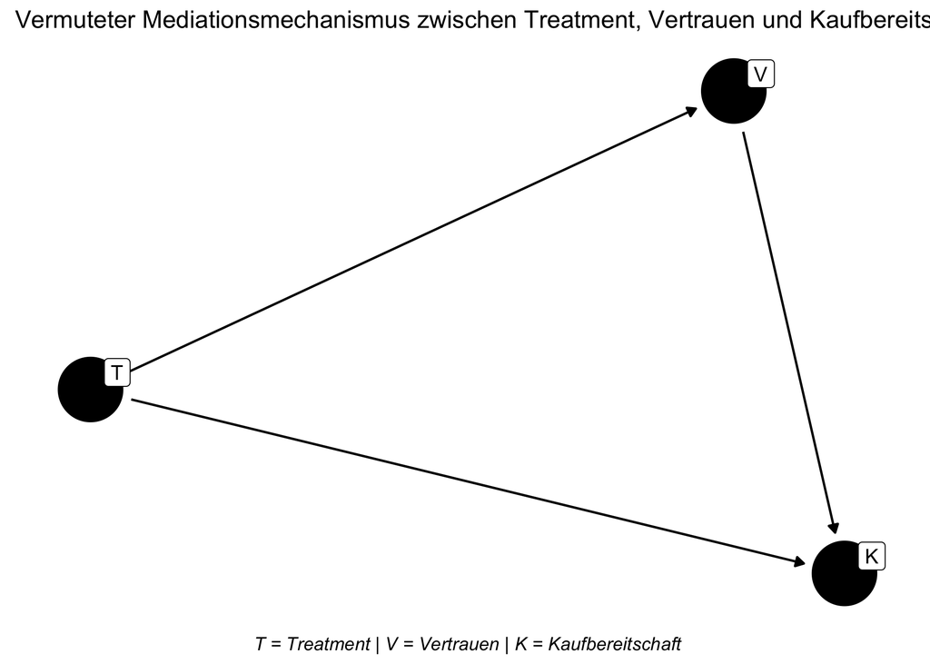

**Beschreibung des DAG´s**

Der DAG (gerichteter azyklischer Graph) stellt ein kausales Modell dar, das die vermuteten Wirkmechanismen zwischen den drei zentralen Variablen deines Experiments visualisiert: Treatment (T), Vertrauen (V) und Kaufbereitschaft (K).  
In diesem DAG existieren drei gerichtete Kanten:

- T → V: Diese Kante stellt die Annahme dar, dass das Treatment – also die Offenlegung der Produktionskosten (Kostentransparenz) – einen Einfluss auf das Vertrauen der Konsument:innen hat. Transparenz soll demnach Vertrauen schaffen.
- V → K: Diese Kante bildet die Hypothese ab, dass Vertrauen in ein Unternehmen die Kaufabsicht gegenüber dem Produkt erhöht. Je vertrauenswürdiger die Marke eingeschätzt wird, desto eher wird eine Kaufabsicht geäußert.
- T → K: Diese direkte Verbindung zwischen Treatment und Kaufbereitschaft erlaubt es, sowohl direkte als auch indirekte (vermittelte) Effekte der Kostentransparenz zu modellieren. Dieser Pfad stellt sicher, dass auch überprüft werden kann, ob Transparenz selbst – unabhängig vom Vertrauen – die Kaufentscheidung beeinflusst.

In Summe ergibt sich eine typische Mediationsstruktur:

- Treatment (T) beeinflusst Vertrauen (V),
- Vertrauen (V) beeinflusst Kaufbereitschaft (K),
- Und Treatment (T) kann zusätzlich direkt Kaufbereitschaft (K) beeinflussen.

Da es keine Rückkanten (Zyklen) gibt, ist der Graph azyklisch und damit für kausale Analyse gültig.

**Interpretation des DAGs**

Der DAG bildet den theoretischen Mechanismus ab, der in deinem Experiment getestet wird: Wirkt Vertrauen als psychologischer Vermittler (Mediator) zwischen Kostentransparenz und Kaufbereitschaft?  
Die Existenz des Pfades T → V → K beschreibt genau diesen vermuteten kausalen Mechanismus:

- Wenn Kostentransparenz (T) Vertrauen (V) stärkt, und
- Wenn Vertrauen (V) die Kaufabsicht (K) erhöht,
- Dann wirkt Vertrauen als vermittelnde Variable (Mediator) zwischen Treatment und Kaufbereitschaft.

Gleichzeitig erlaubt der direkte Pfad T → K, zu überprüfen, ob Treatment auch ohne Vertrauen direkt die Kaufabsicht beeinflusst – etwa durch moralische Überzeugung oder andere affektive Mechanismen. Dieser Pfad ist wichtig, um die Größe und Bedeutung des indirekten Effekts (über Vertrauen) mit dem direkten Effekt zu vergleichen.  
Wenn in der Regressionsanalyse der direkte Effekt (T → K) nicht mehr signifikant wird, sobald Vertrauen (V) im Modell enthalten ist, spricht das für eine vollständige Mediation. Der Effekt von Treatment auf Kaufbereitschaft läuft dann vollständig über Vertrauen.

**Welche Annahmen müssen getroffen werden, damit Vertrauen tatsächlich als Mediator interpretiert werden kann?**

Damit Vertrauen (V) kausal als Mediator interpretiert werden kann, müssen mehrere strenge Annahmen erfüllt sein:

- Kausalität zwischen den Variablen:
  - Das Treatment (T) muss ursächlich auf Vertrauen (V) wirken.
  - Vertrauen (V) muss ursächlich auf Kaufbereitschaft (K) wirken.
  - Die Richtung der Kausalität muss stimmen (z.B. nicht: hohe Kaufabsicht erzeugt mehr Vertrauen).
- Keine unbeobachteten Confounder:
  - Zwischen T und V, V und K, sowie T und K darf es keine unbeobachteten Drittvariablen geben, die gleichzeitig beide Endpunkte beeinflussen. Solche Variablen würden zu Scheinkorrelationen führen.
  - Beispiel: Wenn z.B. eine allgemeine „Vertrauensneigung“ oder politische Einstellung sowohl Vertrauen als auch Kaufbereitschaft beeinflusst, aber nicht gemessen wurde, ist die Mediation verzerrt.
- Keine Rückkopplung oder simultane Kausalität:
  - Vertrauen darf nicht durch Kaufbereitschaft beeinflusst werden – das wäre eine Rückkopplung und widerspricht der Annahme eines azyklischen (gerichteten) Graphen.
  - Die Reihenfolge der Kausalität muss klar definiert sein: T → V → K.
- Keine Messfehler in den Variablen:
  - Vertrauen muss valide und zuverlässig gemessen werden. Ungenaue Messung könnte die Rolle als Mediator verfälschen.

Nur wenn all diese Bedingungen zutreffen (oder durch Studiendesign – z.B. durch Randomisierung – plausibel gemacht werden), kann Vertrauen als kausaler Mediator interpretiert werden.

**Welche Verzerrungen oder Störfaktoren könnten den Mediator-Effekt von Vertrauen beeinflussen?**

Es gibt mehrere potenzielle Verzerrungsquellen, die die Schätzung des Mediator-Effekts von Vertrauen gefährden könnten:

- Nicht erfasste Persönlichkeitsmerkmale oder Einstellungen:
  - Teilnehmer:innen, die generell vertrauensvoll sind (Persönlichkeitseigenschaft), könnten sowohl auf das Treatment positiv reagieren als auch eine hohe Kaufbereitschaft zeigen – unabhängig vom spezifischen Inhalt der Infografik.
  - Wenn diese Eigenschaft nicht gemessen wurde, verzerrt sie die Pfade T → V und V → K.
- Soziale Erwünschtheit oder strategisches Antwortverhalten:
  - Teilnehmer:innen könnten absichtlich ein höheres Vertrauen oder eine höhere Kaufabsicht angeben, weil sie denken, das sei die „richtige“ oder „ethische“ Antwort.
  - Dies führt zu einer systematischen Überschätzung des Mediationseffekts.
- Verzerrte Wahrnehmung der Infografik:
  - Nicht alle Teilnehmer:innen interpretieren die Kostentransparenzgrafik gleich. Einige könnten sie als „Werbetrick“ ansehen, andere als authentisch.
  - Diese subjektive Interpretation beeinflusst direkt, wie stark Vertrauen aufgebaut wird – und damit den Mediator.
- Messfehler in der Variable Vertrauen (trust):
  - Wenn Vertrauen nicht zuverlässig gemessen wird (z.B. durch eine einzelne Skalenfrage), können Schätzfehler entstehen, die zu einer Unterschätzung oder Überschätzung des Mediationseffekts führen.
- Endogenität durch Rückkopplungseffekte:
  - Sollte es in Wirklichkeit so sein, dass ein hohes Kaufinteresse das Vertrauen beeinflusst (z.B. durch ein „Rationalisieren“ des eigenen Konsumwunsches), wird der Effekt von Vertrauen auf Kaufbereitschaft überschätzt.

Kurz gesagt: Konfundierung, Messfehler und endogene Prozesse können den Mediator-Effekt von Vertrauen erheblich verzerren und müssen durch sorgfältiges Studiendesign oder statistische Kontrolle berücksichtigt werden.

15. Führen Sie nun eine Regression durch, bei der Ihnen `trust` (Vertrauen) als abhängige Variable dient. Weiterhin soll ihnen `treatment` als erklärende Variable dienen. Erstellen sie eine weitere Regression, die zusätzlich noch für die folgenden Variablen kontrolliert: Alter, Einkommensniveau, Bildungsstufe und ob die Personen weiblich sind.

Stellen Sie die Regressionsergebnisse in einer Tabelle mit stargazer oder modelsummary dar!

Beschreiben und interpretieren Sie ihre Ergebnisse. Gehen Sie bei der Interpretation der Ergebnisse insbesondere auf folgende Fragen ein:

- Macht es ihrer Ansicht nach Sinn auf die zusätzlichen Variablen in Regression 2 zu kontrollieren? Worauf müssen Sie besonders achten?
- Was bedeutet ein signifikanter positiver Koeffizient für treatment in Bezug auf Vertrauen?
- Warum ist dieser Pfad (Treatment ➝ Trust) notwendig, damit eine Mediation überhaupt möglich ist?
- Überlegen Sie, ob andere Faktoren, die Sie möglicherweise nicht berücksichtigt haben, diesen Zusammenhang ebenfalls erklären könnten.

**Regressionsergebnisse: Einfluss von Kostentransparenz auf Vertrauen**

| Variable | Nur Treatment (SE) | Mit Kontrollvariablen (SE) |
| --- | --- | --- |
| Intercept | 4.821 (0.079)*** | 4.716 (0.320)*** |
| Kostentransparenz (Treatment) | 0.473 (0.112)*** | 0.454 (0.113)*** |
| Alter | NA | -0.001 (0.005) |
| Einkommen | NA | -0.021 (0.024) |
| Bildungsniveau | NA | 0.058 (0.067) |
| Geschlecht: weiblich | NA | 0.179 (0.114) |
| R² | 0.029 | 0.035 |
| Adj. R² | 0.027 | 0.027 |
| F-Statistik | 17.79 (df = 1, 599) | 4.29 (df = 5, 595) |
| AIC | 2091.29 | 2095.59 |
| BIC | 2104.48 | 2126.38 |
| Beobachtungen | 601 | 601 |

*Signifikanz: *** p < 0.001, ** p < 0.01, * p < 0.05*

**Beschreibung der Grafik:**

Die vorliegende Tabelle zeigt die Regressionsergebnisse, die den Einfluss von Kostentransparenz auf Vertrauen untersuchen. Sie ist in zwei Hauptspalten unterteilt: “Nur Treatment (SE)” und “Mit Kontrollvariablen (SE)”. Beide Spalten zeigen die geschätzten Koeffizienten der jeweiligen Variablen sowie deren Standardfehler in Klammern.  
In der Spalte “Nur Treatment (SE)” sind die Koeffizienten für den Intercept (4.821) und die Variable “Kostentransparenz (Treatment)” (0.473) aufgeführt. Darunter sind statistische Kennzahlen wie der R²-Wert (0.029), der Adj. R² (0.027), die F-Statistik (17.79 mit 1 und 599 Freiheitsgraden), der AIC (2091.29) und der BIC (2104.48) angegeben. Die Anzahl der Beobachtungen für dieses Modell beträgt 601.  
Die Spalte “Mit Kontrollvariablen (SE)” listet zusätzlich zu den bereits genannten Variablen die Koeffizienten für Alter (-0.001), Einkommen (-0.021), Bildungsniveau (0.058) und Geschlecht: weiblich (0.179) auf. Die statistischen Kennzahlen für dieses Modell sind ein R² von 0.035, ein Adj. R² von 0.027, eine F-Statistik von 4.29 (mit 5 und 595 Freiheitsgraden), ein AIC von 2095.59 und ein BIC von 2126.38. Die Anzahl der Beobachtungen ist auch hier 601.  
Die Signifikanzniveaus der Koeffizienten werden durch Sternchen markiert: drei Sternchen (***) stehen für p<0.001.

**Interpretation der Grafik:**

Im vorliegenden Fall sehen wir, dass der Koeffizient für “Kostentransparenz (Treatment)” auch nach der Aufnahme der Kontrollvariablen weiterhin hochsignifikant und mit 0.454 nur geringfügig kleiner ist als im ersten Modell (0.473). Dies deutet darauf hin, dass der positive Effekt der Kostentransparenz auf das Vertrauen robust ist und nicht primär durch die demografischen Merkmale erklärt wird. Die Kontrollvariablen selbst (Alter, Einkommen, Bildungsniveau, Geschlecht) zeigen in diesem Datensatz keine signifikanten Effekte auf das Vertrauen, was bedeutet, dass sie zwar im Modell enthalten sind, aber keinen statistisch bedeutsamen Beitrag zur Erklärung des Vertrauens leisten.

**Macht es Sinn, auf zusätzliche Variablen zu kontrollieren? Worauf müssen Sie besonders achten?:**

Ja normalerweiße ist es sinnvoll die Regressionsanalyse mit zusätzlichen Variablen zu vergleichen, da diese Kontrollvariabblen den effekt der unabhängigen variable(hier: Kostentranzparenz) auf die abhängige Variable (hier: Vertrauen) beeinflussen oder verzerren können, wenn man diese nicht berücksichtigt. Wenn man anhand dieser Beispiele Kontrolliert, stellt man sicher das der beobachtete zusammenhang nicht durch externe faktoren beeinflusst wird.  
Besonders beachten sollte man dabei:

- keine willkürliche Auswahl von Kontrollvariablen, sondern die Variablen verwenden, die mit dem Thema in Verbindung stehen könnten
- keine Multikollinearität, das bedeutet keine Kontrollvariablen die zu stark miteinander korrelieren, da dies es erschwert die Individuelle effekte der Variablen genau zu bestimmen aufgrund zu großer Standartfehler

**Was bedeutet ein signifikanter positiver Koeffizient für “Treatment” in Bezug auf Vertrauen?**

Ein signifikanter positiver Koeffizient für “Kostentransparenz (Treatment)” bedeutet, dass die Intervention der Kostentransparenz einen statistisch bedeutsamen und positiven Einfluss auf das Vertrauen hat. Speziell der Koeffizient von 0.454 (im Modell mit Kontrollvariablen) impliziert, dass Personen, die der Bedingung der Kostentransparenz ausgesetzt waren, im Durchschnitt ein um etwa 0.454 Einheiten höheres Vertrauen aufweisen als Personen in der Kontrollgruppe oder ohne diese Transparenz. Die hohe Signifikanz (***, p<0.001) unterstreicht, dass dieses Ergebnis sehr unwahrscheinlich zufällig ist und somit ein verlässlicher Beleg für den positiven Effekt der Kostentransparenz auf das Vertrauen vorliegt.

**Warum ist dieser Pfad (Treatment → Trust) notwendig, damit eine Mediation überhaupt möglich ist?**

Der Pfad von der unabhängigen Variable (hier “Treatment” oder Kostentransparenz) zum vermuteten Mediator (hier “Trust” oder Vertrauen) ist eine grundlegende Voraussetzung für eine Mediation. Eine Mediation liegt vor, wenn der Einfluss einer unabhängigen Variable auf eine abhängige Variable durch eine dritte Variable (den Mediator) vermittelt wird.  
Damit Vertrauen als Mediator fungieren könnte, müsste die Kostentransparenz zunächst das Vertrauen beeinflussen. Wenn Kostentransparenz keinen signifikanten Einfluss auf das Vertrauen hätte (also der Pfad “Treatment → Trust” nicht signifikant wäre), dann könnte Vertrauen nicht der Mechanismus sein, durch den Kostentransparenz eine weitere Variable (z.B. Kaufbereitschaft oder Kundenzufriedenheit) beeinflusst. Vertrauen könnte in diesem Fall keine vermittelnde Rolle spielen, da es selbst nicht durch die Intervention der Kostentransparenz angestoßen würde. Das Ergebnis, dass der Pfad “Kostentransparenz (Treatment) → Trust” hochsignifikant ist, zeigt, dass Vertrauen eine Rolle als Mediator spielen könnte, falls man weitere Outcome-Variablen untersuchen wollte.

**Überlegen Sie, ob andere Faktoren, die Sie möglicherweise nicht berücksichtigt haben, diesen Zusammenhang ebenfalls erklären könnten.**

Ja, es ist sehr wahrscheinlich, dass weitere Faktoren, die in den vorliegenden Regressionsmodellen nicht berücksichtigt wurden, den Zusammenhang zwischen Kostentransparenz und Vertrauen ebenfalls erklären oder beeinflussen könnten. Dies ist besonders offensichtlich durch die relativ niedrigen R²-Werte (0.029 und 0.035), die darauf hindeuten, dass nur ein kleiner Teil der Varianz im Vertrauen durch die einbezogenen Variablen erklärt wird. Ein Großteil der Variation bleibt unaufgeklärt, was auf Ausgelassene-Variablen-Verzerrungen (Omitted Variable Bias) hindeuten kann.  
Mögliche unberücksichtigte Faktoren könnten sein:

- Vorherige Erfahrungen und Erwartungen: Wenn Personen bereits positive oder negative Erfahrungen mit dem Anbieter oder ähnlichen Dienstleistungen gemacht haben, könnte dies ihr Grundvertrauen und ihre Reaktion auf Kostentransparenz beeinflussen.
- Reputation des Anbieters: Der allgemeine Ruf oder die Markenwahrnehmung des Unternehmens, das die Kostentransparenz anbietet, könnte einen erheblichen Einfluss auf das Vertrauen haben, unabhängig von der spezifischen Transparenzmaßnahme.
- Wahrgenommene Fairness der Preise: Transparenz bedeutet nicht automatisch Fairness. Wenn Kunden die offengelegten Kosten als unangemessen oder unfair empfinden, könnte dies das Vertrauen trotz Transparenz untergraben.
- Persönlichkeitsmerkmale: Individuelle Persönlichkeitszüge wie eine allgemeine Vertrauensneigung (Trait-Trust), Skepsis oder Risikobereitschaft könnten moderieren, wie stark Kostentransparenz das Vertrauen beeinflusst.
- Kommunikationsqualität der Transparenz: Nicht nur ob Kosten transparent sind, sondern wie sie kommuniziert werden (z.B. klar, verständlich, übersichtlich vs. kompliziert, versteckt in Details), könnte die Wirkung auf das Vertrauen erheblich beeinflussen.
- Art des Produkts/der Dienstleistung: In manchen Branchen oder bei bestimmten Produkten/Dienstleistungen (z.B. Finanzprodukte, medizinische Behandlungen) ist das Vertrauen von Natur aus komplexer und die Wirkung von Transparenz könnte sich anders entfalten.

Die Nichtberücksichtigung solcher Faktoren könnte dazu führen, dass der geschätzte Effekt der Kostentransparenz auf das Vertrauen entweder überschätzt oder unterschätzt wird, da diese Faktoren möglicherweise sowohl mit der Kostentransparenz als auch mit dem Vertrauen korrelieren.

16. Nachdem Sie nun den Effekt des Treatments auf das Vertrauen geschätzt und ausgewertet haben, sollen Sie nun testen, ob das Vertrauen als Mediator zwischen Treatment und Kaufabsicht wirkt.

Führen Sie eine Regression durch, bei der Ihnen die Kaufbereitschaft als abhängige Variable dient. Weiterhin sollen die erklärende Variablen nun `treatment`, sowie das Vertrauen (`trust`) umfassen. Erstellen sie eine weitere Regression, die zusätzlich noch auf Alter, Einkommensniveau, Bildungsstufe und ob die Personen weiblich sind, kontrolliert.

Stellen Sie die Regressionsergebnisse passend in einer Tabelle dar!

Beschreiben und interpretieren Sie ihre Ergebnisse. Gehen Sie bei der Interpretation der Ergebnisse insbesondere auf folgende Fragen ein:

- Was könnten Ihrer Ansicht nach Gründe sein, dass `treatment` jetzt nicht mehr signifkant ist? Woran könnt das im Detail liegen?
- Warum ist es wichtig, `trust` und `treatment` gemeinsam in einem Modell zu betrachten?
- Warum könnte `trust` eine “notwendige Bedingung” sein, damit Transparenz der Kostenstruktur zu höherer Kaufbereitschaft führt?

**Regressionsergebnisse: Mediation (Kaufbereitschaft ~ Treatment + Vertrauen)**

| Variable | Nur Treatment & Vertrauen (SE) | Mit Kontrollvariablen (SE) |
| --- | --- | --- |
| Intercept | -0.178 (0.260) | -0.155 (0.457) |
| Kostentransparenz (Treatment) | 0.148 (0.140) | 0.129 (0.140) |
| Vertrauen | 0.813 (0.050)*** | 0.818 (0.050)*** |
| Alter | NA | -0.013 (0.006)* |
| Einkommen | NA | 0.041 (0.030) |
| Bildungsniveau | NA | 0.055 (0.082) |
| Geschlecht: weiblich | NA | -0.148 (0.140) |
| R² | 0.317 | 0.327 |
| Adj. R² | 0.315 | 0.32 |
| F-Statistik | 139.01 (df = 2, 598) | 48.03 (df = 6, 594) |
| AIC | 2337.9 | 2337.67 |
| BIC | 2355.5 | 2372.86 |
| Beobachtungen | 601 | 601 |

*Signifikanz: *** p < 0.001, ** p < 0.01, * p < 0.05*

**Beschreibung der Ergebnisse**

Die Tabelle enthält die Ergebnisse zweier linearer Regressionsmodelle zur Erklärung der Kaufbereitschaft der Teilnehmer:innen für das Produkt „Cocoa Passion“. Die abhängige Variable ist jeweils die selbstberichtete Kaufbereitschaft (auf einer Skala von 1 bis 7).

- Modell 1 – Nur Treatment und Vertrauen:  
  Dieses Modell umfasst zwei erklärende Variablen: die experimentelle Bedingung „Treatment“ (Kostentransparenz vs. keine Kostentransparenz) sowie das Vertrauen („trust“) in das Unternehmen.
  - Intercept: Der Achsenabschnitt liegt bei -0.178 mit einem Standardfehler von 0.260. Dieser Wert ist nicht signifikant und stellt die geschätzte Kaufbereitschaft dar, wenn beide Prädiktoren (Treatment und Trust) den Wert 0 annehmen – was in der Praxis schwer interpretierbar ist, da Trust auf einer Skala von 1 bis 7 vorliegt.
  - Kostentransparenz (Treatment): Der Koeffizient beträgt 0.148 mit einem Standardfehler von 0.140. Dieser Effekt ist statistisch nicht signifikant, was bedeutet, dass Kostentransparenz allein – kontrolliert für Vertrauen – keinen eindeutigen Einfluss auf die Kaufbereitschaft hat.
  - Vertrauen (Trust): Der Effekt von Vertrauen auf Kaufbereitschaft ist hoch signifikant (p < .001) mit einem Koeffizienten von 0.813 und einem sehr kleinen Standardfehler von 0.050. Dies deutet auf einen starken positiven Zusammenhang zwischen dem Vertrauen in das Unternehmen und der Kaufabsicht hin.
  - Modellgüte (R² und Adj. R²): Das Modell erklärt 31,7 % (R² = 0.317) der Varianz der Kaufbereitschaft. Das adjustierte R² (korrigiert für die Anzahl der Prädiktoren) liegt bei 0.315. Die F-Statistik (139.01) ist hochsignifikant, was zeigt, dass das Modell insgesamt erklärungskräftig ist.
  - Informationskriterien (AIC/BIC): AIC = 2337.9, BIC = 2355.5 – dienen dem Vergleich von Modellen, je niedriger desto besser.
- Modell 2 – Mit Kontrollvariablen:  
  In diesem erweiterten Modell wurden zusätzlich Alter, Einkommen, Bildungsniveau und Geschlecht (weiblich) als Kontrollvariablen aufgenommen.
  - Intercept: Der Intercept liegt nun bei -0.155 (SE = 0.457), ebenfalls nicht signifikant. Die Interpretation bleibt hier rein formal.
  - Kostentransparenz (Treatment): Der Effekt sinkt leicht auf 0.129 (SE = 0.140), bleibt aber weiterhin nicht signifikant.
  - Vertrauen (Trust): Der Effekt bleibt fast unverändert bei 0.818 (SE = 0.050) und ist weiterhin hoch signifikant (p < .001).
  - Alter: Der Effekt ist negativ (-0.013) und mit einem Standardfehler von 0.006 statistisch signifikant (p < .05). Das heißt, mit zunehmendem Alter nimmt die Kaufbereitschaft leicht ab.
  - Einkommen: Der Koeffizient ist positiv (0.041), jedoch mit einem SE von 0.030 nicht signifikant.
  - Bildung: Ein positiver, aber kleiner Koeffizient (0.055) mit einem relativ hohen Standardfehler (0.082) – ebenfalls nicht signifikant.
  - Geschlecht (weiblich): Der negative Koeffizient (-0.148) deutet darauf hin, dass weibliche Teilnehmer:innen tendenziell geringere Kaufbereitschaft zeigen, ist jedoch statistisch nicht signifikant.
  - Modellgüte: Das R² steigt leicht auf 0.327 (Adj. R² = 0.320). Das bedeutet, das Modell erklärt nun 32,7 % der Varianz. Die F-Statistik bleibt hoch (48.03) und signifikant.
  - Informationskriterien: AIC und BIC sind nahezu identisch mit dem vorherigen Modell (leichter Rückgang im AIC, Anstieg im BIC durch die zusätzlichen Parameter).

**Interpretation der Regressions-Tabelle**

Die zentrale Erkenntnis aus beiden Modellen lautet: Vertrauen ist ein hoch signifikanter Prädiktor für Kaufbereitschaft. Je höher das Vertrauen der Konsument:innen in das Unternehmen, desto stärker die selbst eingeschätzte Bereitschaft, das Produkt zu kaufen.  
In beiden Modellen verliert die Treatment-Variable (Kostentransparenz) ihre Signifikanz, sobald Vertrauen als erklärende Variable enthalten ist. Das legt nahe, dass der Effekt von Transparenz auf Kaufbereitschaft vollständig über Vertrauen vermittelt wird – also ein klassischer Fall für eine Mediationsanalyse.  
Die Kontrollvariablen (Alter, Einkommen, Bildung, Geschlecht) liefern keine substanziellen Erklärungsbeiträge, mit Ausnahme von Alter, das einen leicht negativen Effekt auf die Kaufbereitschaft hat. Das bedeutet, dass ältere Teilnehmer:innen etwas skeptischer oder weniger kaufbereit gegenüber dem präsentierten Produkt sind.  
Der leichte Anstieg von R² im zweiten Modell zeigt, dass die Kontrollvariablen zwar etwas zur Erklärung beitragen, aber der zentrale Treiber der Kaufbereitschaft bleibt das Vertrauen – und nicht demografische Merkmale oder die reine Transparenz an sich.

**Was könnten Ihrer Ansicht nach Gründe sein, dass treatment jetzt nicht mehr signifikant ist?**

Dass der Treatment-Effekt im Regressionsmodell nicht mehr signifikant ist, liegt sehr wahrscheinlich daran, dass dessen Wirkung vollständig durch Vertrauen vermittelt wird.  
Sobald Vertrauen im Modell enthalten ist, „erklärt“ es den Effekt der Transparenz vollständig. Die Transparenz selbst führt also nicht direkt zur höheren Kaufbereitschaft, sondern sie erhöht das Vertrauen, was wiederum die eigentliche Ursache der erhöhten Kaufbereitschaft ist.  
Im statistischen Sinn bedeutet das: Die beiden Variablen (Treatment und Trust) sind korreliert, aber nur Trust ist der direkte Prädiktor für die abhängige Variable (Kaufbereitschaft). Daher verliert Treatment seine Signifikanz, sobald Trust im Modell ist – ein typischer Fall für einen mediierenden Mechanismus.  
Zusätzliche mögliche Gründe:

- Die Effektgröße von Treatment ist relativ klein.
- Es gibt individuelle Unterschiede in der Wahrnehmung von Transparenz, die nicht alle durch die Treatment-Variable allein erfasst werden.
- Measurement noise: Vertrauen wird direkt erfragt, während Treatment eine „harte“ experimentelle Variable ist, die individuelle Reaktionen nicht direkt abbildet.

**Warum ist es wichtig, trust und treatment gemeinsam in einem Modell zu betrachten?**

Trust und Treatment gemeinsam im Modell zu analysieren ist entscheidend, um zu verstehen, wie der Effekt der Transparenz „wirkt“. Nur durch die gemeinsame Betrachtung wird deutlich:

- Ob Treatment überhaupt noch eine direkte Wirkung auf die Kaufbereitschaft hat, wenn Vertrauen kontrolliert wird.
- Wie groß der indirekte Effekt über Vertrauen ist – das ist entscheidend für die Mechanismusanalyse.

Ohne Trust im Modell würden wir fälschlicherweise annehmen, Transparenz an sich erhöhe die Kaufabsicht. Das gemeinsame Modell zeigt: Nicht die Transparenz allein ist kaufentscheidend, sondern das durch sie ausgelöste Vertrauen. Das ist ein fundamentaler Unterschied für Unternehmensstrategien: Es reicht nicht, Kosten offen zu legen – es muss auch Vertrauen entstehen.  
Außerdem zeigt das gemeinsame Modell, ob Vertrauen eine vermittelnde (mediierende) oder moderierende Rolle spielt – also ob es lediglich vermittelt oder auch die Stärke des Effekts verändert.

**Warum könnte trust eine “notwendige Bedingung” sein, damit Transparenz der Kostenstruktur zu höherer Kaufbereitschaft führt?**

Vertrauen kann als notwendige Bedingung verstanden werden, weil Kostentransparenz ohne daraus resultierendes Vertrauen wirkungslos bleibt. Die reine Information über Produktionskosten hat keinen Wert, wenn sie nicht als Glaubwürdigkeits- oder Fairnesssignal verstanden wird.  
Psychologisch gesehen funktioniert Vertrauen als ein Vermittler sozialer Qualität:

- Transparenz allein sagt noch nichts über gute Absichten aus.
- Vertrauen hingegen deutet auf eine moralische Bewertung hin („dieses Unternehmen ist ehrlich, verantwortungsvoll, fair“).

Wenn ein:e Konsument:in die Offenlegung von Produktionskosten sieht, aber daraus kein Vertrauen schöpft (z.B. weil er/sie das Unternehmen dennoch als gewinnorientiert oder manipulativ wahrnimmt), wird sich die Kaufbereitschaft nicht verändern.  
Daher ist Vertrauen nicht nur ein Mediator, sondern auch eine Bedingung für die Wirksamkeit der Intervention. Erst wenn Vertrauen etabliert wird, entfaltet die Transparenz ihre kaufverhaltensverändernde Kraft.  
In der Praxis bedeutet das: Unternehmen müssen nicht nur transparent sein, sondern auch die Art der Präsentation und den Kontext so gestalten, dass daraus tatsächlich Vertrauen entsteht.

In den vorangegangenen Modellen wurde untersucht, ob das Treatment (Kostentransparenz) das Vertrauen in das Unternehmen beeinflusst und ob Vertrauen wiederum mit der Kaufabsicht zusammenhängt.

17. Bewerten Sie das experimentelle Design der Studie 2. Gehen Sie dabei auch darauf ein, inwiefern Ihre Ergebnisse aus Aufgabe 13 bis 16 das theoretische Verständnis von Vertrauensbildung in der Konsumentenpsychologie bestätigt oder infrage stellt. Welche Stärken und Schwächen sehen Sie bezüglich der internen Validität und der Kausalitätsaussagen? Diskutieren Sie zudem kurz, inwiefern die Ergebnisse auf andere Bevölkerungsgruppen oder kulturelle Kontexte übertragbar sind.

*Hinweis:* Informationen zum Verständnis der Vertrauensbildung in der Konsumentenpsychologie können Sie [in dem folgenden Artikel](https://www.shs-conferences.org/articles/shsconf/pdf/2021/26/shsconf_appsconf2021_03019.pdf) auf Seite 2 bis 5 nachlesen.

**Bewertung des experimentellen Designs der Studie 2**

Die vorliegende Studie verwendet ein experimentelles Design, um den Effekt von Kostentransparenz auf das Konsumentenvertrauen sowie dessen Mediatorrolle hinsichtlich der Kaufbereitschaft zu untersuchen. Diese Struktur erlaubt grundsätzlich valide kausale Aussagen, sofern zentrale Annahmen erfüllt sind.

**Bestätigung des theoretischen Verständnisses**

Die Ergebnisse der Aufgaben 13 bis 16 unterstützen deutlich das theoretische Verständnis von Vertrauensbildung in der Konsumentenpsychologie (vgl. SHS Conference, 2021, S. 2–5). Vertrauen wird hier als kritischer Mechanismus dargestellt, der Transparenzmaßnahmen effektiv werden lässt. Konkret bestätigen die empirischen Resultate, dass Kostentransparenz Unsicherheit reduziert, Glaubwürdigkeit steigert und somit entscheidend für eine positive Kaufentscheidung ist. Damit wird Vertrauen als zentrale und notwendige Vermittlungsinstanz bestätigt, und nicht lediglich als Randphänomen dargestellt.

**Stärken der internen Validität und Kausalität**

Eine wesentliche Stärke des Designs ist die Randomisierung der Teilnehmer in Treatment- und Kontrollgruppen. Diese Vorgehensweise reduziert systematische Verzerrungen durch unbeobachtete Variablen erheblich und verbessert die interne Validität der Studie maßgeblich. Zusätzlich wurden relevante demografische Faktoren (Alter, Einkommen, Bildungsniveau, Geschlecht) in den Regressionsmodellen kontrolliert, was die Robustheit der Ergebnisse deutlich erhöht. Die Stabilität und Signifikanz der gefundenen Effekte (Treatment → Vertrauen und Vertrauen → Kaufbereitschaft) sind statistisch gut abgesichert und unterstützen die Aussagekraft der Kausalschlüsse deutlich.

**Schwächen der internen Validität und mögliche Verzerrungen**

Allerdings bestehen methodische Einschränkungen. Die zeitgleiche Messung von Mediator (Vertrauen) und abhängiger Variable (Kaufbereitschaft) gefährdet die kausale Interpretierbarkeit, da Reverse Causality (rückwirkender Effekt der Kaufabsicht auf Vertrauen) nicht vollständig ausgeschlossen werden kann. Zudem besteht das Risiko sozial erwünschter Antworten, insbesondere in einem Kontext, in dem Transparenz ethisch aufgeladen ist. Teilnehmende könnten Antworten geben, die ihre soziale Erwünschtheit erhöhen oder dem entsprechen, was sie als Ziel der Studie vermuten (vgl. SHS Conference, 2021).

**Übertragbarkeit auf andere Bevölkerungsgruppen und kulturelle Kontexte**

Die Generalisierbarkeit der Befunde ist eingeschränkt. Die verwendete Stichprobe stammt voraussichtlich aus einem westlich geprägten kulturellen Kontext (WEIRD – Western, Educated, Industrialized, Rich, Democratic), der spezifische Wertvorstellungen bezüglich Transparenz und Vertrauen aufweist. Studien zeigen, dass in kollektivistischen Kulturen Vertrauen stärker von Beziehungen und sozialer Harmonie abhängen könnte, während Transparenz allein weniger Wirkung zeigt (vgl. SHS Conference, 2021). Ebenso könnten für Produkte mit höheren Risiken, wie Finanz- oder Gesundheitsprodukte, andere Vertrauenskomponenten, insbesondere Kompetenz und Sicherheit, entscheidender sein.

**Fazit**

Zusammenfassend bietet das experimentelle Design belastbare Hinweise darauf, dass Kostentransparenz primär über die Vermittlung von Vertrauen die Kaufbereitschaft erhöht. Diese Ergebnisse bestätigen zentrale theoretische Annahmen aus der Konsumentenpsychologie. Dennoch sollten aufgrund der genannten methodischen Einschränkungen und der begrenzten Generalisierbarkeit die Befunde mit Vorsicht interpretiert und in weiteren Studien systematisch überprüft werden.

# Zusatzaufgabe

Zu Beginn des Projektes hatten wir erwähnt, dass die Experimente, welche im Projekt durchgeführt wurden, auf Grund eines Missgeschicks in der Online-Darstellung von unterschiedlichen Produkten zustande kam. Hier wurden von einem privat geführten Online-Händler Geldbörsen in fünf Farbvarianten angeboten, wobei beabsichtigt war, allen Farben eine einheitliche Kostentransparenz-Infografik zuzuordnen. Aufgrund eines Versehens wurde die Infografik jedoch nur bei drei Farben implementiert. Dieses zufällige Ereignis führte zu einer klaren Trennung zwischen den Produkten mit dieser und ohne diese Infografik. Das dadurch entstandene natürliche Experiment sollen Sie sich in der Zusatzaufgabe näher anschauen.

18. Lesen Sie sich den nachfolgenden Text zum Aufbau des natürlichen Experiments innerhalb dieses Papers durch und beantworten anschließend nachfolgende Fragen:

On December 2, 2013, a privately held online retailer launched a holiday gift shop with a single email to its mailing list, promoting a leather wallet offered in five colors (burgundy, black, grey, bone, and tan) and priced at $115.00. Later, at the end of January, to boost post-holiday sales, the retailer decided to add a cost transparency infographic to the online product detail pages for each of the wallet’s five color combinations. The retailer’s intention was to use the same infographic for all wallets since they differed only in color.

However, due to an inadvertent mistake, the infographic was not introduced for two of the wallet colors (bone and tan). Consequently, the cost transparency information was implemented for only three of the five wallet colors (burgundy, black, and grey) over a period of five weeks. This error created a natural experiment, enabling us to test the impact of cost transparency on wallet sales.

Therefore we have the following procedure:

- Operationalization of Cost Transparency: The infographic presented the total cost to produce the wallet, breaking it down into its specific components, namely: leather (14.68 US-Dollar), construction (38.56 US-Dollar), duties (4.26 US-Dollar), and transportation (1.00 US-Dollar). In addition, it included benchmark information indicating that the wallet had a 1.9x markup, in contrast to a 6x markup charged by a competitor. Because wallet colors serve as the basis for treatment assignment, the natural experiment compares “cost transparent” wallets (burgundy, black, and grey) to “non-transparent” wallets (bone and tan).
- Identification Strategy: We use a difference-in-differences approach to compare the daily sales between the treatment (cost transparency) and control (no cost transparency) groups before versus after the introduction of the infographic. By doing so, the design isolates the causal effect of cost transparency on the daily count of wallets sold for each color.
- Control Variables: Given that the cost transparency treatment was implemented by wallet color, and with only five available colors, it was necessary to control for potential confounders. For instance, we include a proxy for time-varying color popularity - the number of page views each wallet color received - and a proxy for time-varying inventory levels.

Beantworten Sie nun die folgenden Fragen in Bezug auf den vorherigen Text:

- Wie ist das natürliche Experiment aufgebaut, und warum wird es als solches klassifiziert?
- Welche Rolle spielt das zufällige Versäumnis, die Infografik bei zwei der fünf Farbvarianten einzuführen, in der Experimentstruktur?
- Warum ist es notwendig, Variablen wie Seitenaufrufe und Lagerbestandsproxies in die Analyse einzubeziehen?
  - Welche potenziellen Verzerrungen könnten auftreten, wenn diese Kontrollvariablen nicht berücksichtigt werden?

**Aufbau des natürlichen Experiments und Klassifikation**

Ein Experiment wird dann als „natürlich“ klassifiziert, wenn die Zuweisung in Behandlungs- und Kontrollgruppen nicht durch den Forscher oder die Forscherin selbst erfolgt (wie es bei einem klassischen randomisierten Kontrollgruppendesign der Fall wäre), sondern durch externe, oft zufällige oder unvorhergesehene Umstände. In diesem Fall besteht das natürliche Experiment darin, dass die Kosten-Transparenz-Infografik ursprünglich für alle fünf Farben vorgesehen war, jedoch aufgrund eines unbeabsichtigten Fehlers nur bei drei Farben (burgundy, black und grey) tatsächlich implementiert wurde. Dieser Fehler stellt die Grundlage der zufälligen Zuweisung dar und ist entscheidend für die Kausalinterpretation der Ergebnisse.

**Rolle des zufälligen Versäumnisses**

Das zufällige Versäumnis, die Infografik bei den Farben bone und tan zu implementieren, spielt eine zentrale Rolle im Aufbau des Experiments. Es sorgt dafür, dass die Zuordnung zur Behandlungsgruppe (mit Infografik) und zur Kontrollgruppe (ohne Infografik) nicht systematisch durch bestimmte Eigenschaften der Farben oder der Kundennachfrage bestimmt wurde, sondern unabhängig von solchen Faktoren entstand. Dies erlaubt es, Unterschiede im Verkaufsverhalten vor und nach der Einführung der Infografik plausibel als kausalen Effekt der Kosten-Transparenz zu interpretieren – vorausgesetzt, dass sich andere relevante Einflüsse gleichmäßig auf beide Gruppen ausgewirkt haben.

**Notwendigkeit der Kontrollvariablen**

Obwohl die Zuweisung zur Behandlung quasi-randomisiert erscheint, ist es dennoch notwendig, Kontrollvariablen wie Seitenaufrufe und Lagerbestände in die Analyse einzubeziehen. Der Grund ist, dass sich auch unbeabsichtigte, zeitlich variierende Faktoren auf die Verkaufszahlen der verschiedenen Farbvarianten auswirken können. So könnte zum Beispiel eine bestimmte Farbe aus anderen Gründen (z.B. saisonale Präferenzen, Modeeinflüsse, Erwähnungen in Medien oder sozialen Netzwerken) beliebter werden oder eine andere seltener nachgefragt werden. Ebenso könnten Unterschiede in der Verfügbarkeit einzelner Farben (z.B. durch Lagerknappheit) den Absatz beeinflussen, unabhängig von der Infografik.

**Mögliche Verzerrug ohne Kontrollvariablen**

Würden Seitenaufrufe oder Lagerbestände nicht kontrolliert, könnten sich daraus systematische Verzerrungen in der Schätzung des Effekts der Kosten-Transparenz ergeben. Ein Beispiel: Wenn die Farbe „burgundy“ im gleichen Zeitraum durch Zufall besonders oft aufgerufen wurde, könnte ein Anstieg der Verkäufe fälschlich dem Effekt der Infografik zugeschrieben werden, obwohl er durch eine gesteigerte Aufmerksamkeit verursacht wurde. Ebenso würde ein sinkender Lagerbestand einer Farbe die Verkaufszahlen begrenzen, was ohne Kontrolle zu einer Unterschätzung des Effekts führen könnte. Insgesamt dienen diese Variablen dazu, konkurrierende Hypothesen und alternative Erklärungen auszuschließen und die interne Validität der Analyse zu stärken.

19. Lesen Sie weiterhin das Kapitel [“Difference-in-Differences” in Huntington-Klein (2021)](https://theeffectbook.net/ch-DifferenceinDifference.html), speziell Kapitel 18.1 und 18.2 und beantworten Sie die folgenden Fragen dazu:

Kann eine Difference-in-Differences-Regression helfen, den kausalen Effekt der Kostentransparenz auf die Verkaufszahlen zu identifizieren?

Gehen Sie bei der Beantwortung dieser Frage insbesondere auf die nachfolgenden Punkte ein:

- Welche Art von Variation nutzt eine DiD-Regression in diesem Fall zur Identifikation des Effekts?
- Welche Voraussetzung(en) müssen erfüllt sein, damit DiD eine gültige Kausalschätzung liefert?
  - Was bedeutet die „Parallel Trends“-Annahme in diesem Kontext?
  - Warum reicht es nicht aus, nur zu vergleichen, wie sich die Verkaufszahlen nach der Einführung verändert haben?
- Basierend auf dem Kontext des Buchkapitels zu Difference-in-Differences (DiD) und den Informationen aus `Aufgabe 18`, formulieren Sie bitte die **Regressionsgleichung**, mit der der Effekt der Kostentransparenzmaßnahme mithilfe eines DiD-Ansatzes untersucht werden kann.
  - Definieren Sie dabei klar alle verwendeten Variablen.
  - Stellen Sie die Regressionsgleichung in mathematischer Form dar.
  - Beschreiben und erklären Sie das von Ihnen aufgestellte Modell.

**Identifikation des kausalen Effekts durch eine DiD-Regression**

Ja, eine Difference-in-Differences (DiD)-Regression ist in diesem Fall ein geeignetes methodisches Werkzeug, um den kausalen Effekt der Einführung von Kostentransparenz auf die Verkaufszahlen zu identifizieren. Der entscheidende Vorteil der DiD-Methode besteht darin, dass sie Unterschiede über die Zeit und zwischen Gruppen gleichzeitig berücksichtigt, um Störfaktoren und allgemeine Zeittrends herauszurechnen. In diesem Experiment wurde – unbeabsichtigt – eine Art natürliche Zuweisung von Behandlung und Kontrolle geschaffen: Drei Wallet-Farben erhielten die Infografik (Behandlungsgruppe), zwei Farben nicht (Kontrollgruppe). Durch die Kombination der zeitlichen Dimension (vor vs. nach Einführung der Infografik) mit der Gruppendimension (mit vs. ohne Infografik) lässt sich der spezifische Effekt der Kostentransparenz auf den Absatz isoliert untersuchen – vorausgesetzt, gewisse Annahmen, insbesondere die der „parallelen Trends“, sind erfüllt. Die DiD-Regression ermöglicht also eine kausale Interpretation unter relativ realitätsnahen Bedingungen, was sie besonders wertvoll für ökonomische Feldexperimente wie dieses macht.

**Art der Variation**

Die DiD-Regression nutzt zwei zentrale Quellen der Variation: zeitliche Variation und Querschnittsvariation zwischen Gruppen. Erstens analysiert sie die Veränderung der Verkaufszahlen über die Zeit hinweg, d.h. vor und nach der Einführung der Kostentransparenz-Infografik. Diese Variation betrifft sowohl die Behandlungs- als auch die Kontrollgruppe. Zweitens nutzt sie Unterschiede zwischen den Wallet-Farben, von denen einige die Infografik erhielten und andere nicht. Diese Gruppenzuweisung geschah zufällig (durch einen Fehler) und bildet somit die Basis für einen plausiblen kausalen Vergleich. Die DiD-Analyse betrachtet die Differenz zwischen der zeitlichen Veränderung in der Behandlungsgruppe und der zeitlichen Veränderung in der Kontrollgruppe. Durch diese Kombination können Einflüsse, die alle Farben gleichermaßen über die Zeit betreffen (z.B. Nachfragerückgänge nach den Feiertagen oder saisonale Muster), aus der Schätzung herausgerechnet werden. Es wird also nicht einfach nur der Unterschied innerhalb der behandelten Farben vor und nach der Infografik betrachtet, sondern dieser Unterschied wird relativ zur Entwicklung bei den unbehandelten Farben interpretiert – daher „Difference-in-Differences“.

**Voraussetzungen**

Die wichtigste Voraussetzung für eine valide Kausalschätzung mit der DiD-Methode ist die sogenannte „Parallel Trends“-Annahme. Diese Annahme besagt, dass sich die Verkaufszahlen der Behandlungs- und Kontrollgruppe ohne die Einführung der Infografik gleichartig entwickelt hätten, also einem gemeinsamen Trend über die Zeit folgen. Das bedeutet, dass der einzige systematische Unterschied in der Entwicklung nach der Intervention auf die Maßnahme selbst (die Infografik) zurückzuführen ist. Diese Annahme lässt sich nicht direkt testen, kann aber durch die Analyse von Trends vor der Einführung der Maßnahme gestützt werden. Wenn sich beispielsweise die Verkaufszahlen beider Gruppen im Zeitraum vor der Infografik ähnlich entwickelt haben, ist es plausibler, dass auch danach ein paralleler Trend bestanden hätte – wäre die Infografik nicht eingeführt worden. Sollte diese Annahme verletzt sein (z.B. weil eine Farbe ohnehin im Trend lag), könnten andere Faktoren als die Infografik für die beobachteten Effekte verantwortlich sein. Deshalb ist es entscheidend, diese Annahme sowohl konzeptionell als auch empirisch kritisch zu prüfen, etwa durch Visualisierung von Vorperioden-Trends oder durch sogenannte Placebo-Tests.

**Bedeutung der “Parallel Trends”**

Im konkreten Kontext des Wallet-Experiments bedeutet die „Parallel Trends“-Annahme, dass sich die Verkaufszahlen der verschiedenen Wallet-Farben ohne die Einführung der Kostentransparenz-Infografik über die Zeit hinweg ähnlich entwickelt hätten. Anders ausgedrückt: Wenn es den Fehler bei der Implementierung nicht gegeben hätte und alle Farben gleich behandelt worden wären (z.B. keine Infografik für alle), dann hätten sich die Verkaufszahlen der drei „Behandlungsfarben“ (burgundy, black, grey) in einem ähnlichen Muster wie die der „Kontrollfarben“ (bone, tan) verändert. Wenn diese Bedingung erfüllt ist, kann man davon ausgehen, dass ein Unterschied in der Entwicklung der Verkaufszahlen nach Einführung der Infografik tatsächlich auf die Infografik selbst zurückzuführen ist – und nicht auf andere, gruppenspezifische Entwicklungen. Die Plausibilität dieser Annahme wird im Allgemeinen durch Betrachtung der Trends vor der Intervention überprüft. Wenn die Verkaufskurven beider Gruppen vor der Infografik parallel verlaufen, unterstützt das die Gültigkeit der DiD-Schätzung.

**Kein ausreichender Vergleich der Verkaufszahlen**

Ein bloßer Vorher-Nachher-Vergleich innerhalb der Behandlungsgruppe würde nicht ausreichen, um den kausalen Effekt der Kostentransparenz zu identifizieren. Das liegt daran, dass viele andere Faktoren ebenfalls die Verkaufszahlen beeinflussen können – insbesondere zeitabhängige Einflüsse wie saisonale Schwankungen, gesamtwirtschaftliche Trends oder Nachfragerückgänge nach der Weihnachtszeit. Wenn man nur betrachtet, dass sich die Verkaufszahlen nach Einführung der Infografik verändert haben, lässt sich nicht feststellen, ob diese Veränderung tatsächlich durch die Infografik oder durch solche allgemeinen Zeitfaktoren verursacht wurde. Die Kontrollgruppe fungiert hier als Gegentrend, der zeigt, wie sich die Verkaufszahlen entwickelt hätten, wenn keine Infografik eingeführt worden wäre. Nur durch den Vergleich mit dieser Kontrollgruppe kann man den „wahren“ Effekt der Infografik isolieren – also den Unterschied, der über die allgemeinen Trends hinausgeht.

**Formulierung der Regressionsgleichung**

Um den Effekt der Kostentransparenzmaßnahme zu analysieren, kann eine Difference-in-Differences-Regression wie folgt spezifiziert werden:  
Mathematische Form:  
Y = B0 + B1 * Treat + B2 * Post + B3 * (Treat x Post) + y * X + E  
Definition der Variablen:

- Y: Anzahl verkaufter Einheiten der Wallet-Farbe i am Tag t
- Treat: Dummy-Variable, die 1 ist, wenn i zur Behandlungsgruppe gehört (burgundy, black, grey), sonst 0
- Post: Dummy-Variable, die 1 ist, wenn Tag t nach Einführung der Infografik liegt, sonst 0
- Treat x Post: Interaktionsterm - dieser misst den kausalen Effekt der Kostentransparenz
- X: Vektor an Kontrollvariablen, z.B. Seitenaufrufe und Lagerbestand
- E: Fehlerterm (Restkomponente)

Modellbeschreibung:  
Dieses Regressionsmodell nutzt die DiD-Logik, indem es die durchschnittlichen Veränderungen in den Verkaufszahlen in der Behandlungsgruppe relativ zur Kontrollgruppe nach der Maßnahme quantifiziert. Der Interaktionsterm B3 * (Treat x Post) ist dabei der zentrale DiD-Koeffizient, der den geschätzten Effekt der Infografik auf die Verkaufszahlen angibt. Die Kontrolle über X hilft dabei, zeitlich variierende Störfaktoren wie die Popularität einzelner Farben oder Bestandsengpässe zu berücksichtigen, die sonst die Schätzung verzerren könnten. Wenn das Modell gut spezifiziert ist und die Parallel-Trends-Annahme gilt, kann man B3 als kausale Wirkung der Kostentransparenzmaßnahme interpretieren.

20. Zum Abschluss des Projekts sollen Sie sich das oben beschriebene natürliche Experiment genauer anschauen. Lesen Sie hierzu die Daten (`Experiment3.csv`) in R ein. Nennen Sie den Datensatz `daten_exp3`. Erstellen Sie eine Variable `log_units`, die die logarithmierte Anzahl an verkauften Einheiten darstellt.

Erstellen Sie weiterhin eine passende Grafik, die die durchschnittliche Anzahl der verkauften Produkte je Treatment pro Woche abbildet. Fügen Sie weiterhin eine vertikale Linie für den 28. Januar 2014 in ihre Grafik ein, welche die Einführung der Kostentransparenz markiert.

Beschreiben und interpretieren Sie ihre Grafik. Gehen Sie insbesondere auf die Entwicklung der durchschnittlichen Verkaufszahlen in beiden Gruppen vor und nach dem 28. Januar ein. Gibt es visuelle Hinweise auf eine Wirkung der Kostentransparenz?

- Angenommen, beide Gruppen (Treatment und Kontrolle) zeigen vor der Einführung der Kostentransparenz einen gleich starken Anstieg der durchschnittlich verkauften Einheiten. Was würde das für die Interpretation der Maßnahme im Rahmen eines Difference-in-Differences-Ansatzes bedeuten?

*Hinweis:* Für die Ableitung der Wochen aus dem Datumsformat kann die Funktion `isoweek()` aus dem Paket `lubridate` verwendet werden.

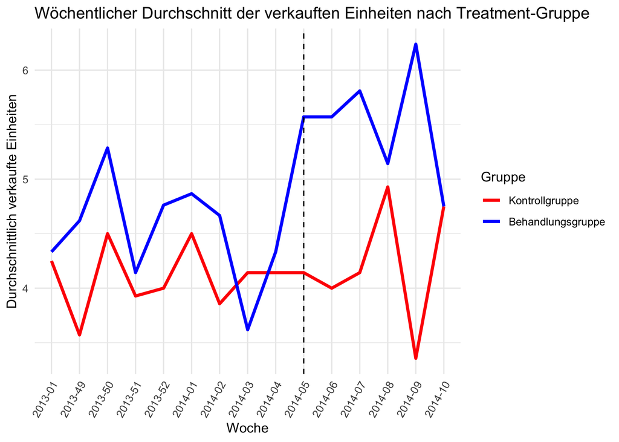

**Interpretation der Grafik**

**Hinweise auf Wirkung der Kostentransparenz**

**DiD Ansatz**

Wenn in einem Difference-in-Differences-Design beide Gruppen – also die Behandlungsgruppe (Treatment) und die Kontrollgruppe (Control) – vor der Einführung einer Maßnahme einen gleich starken Anstieg in der Zielvariable zeigen, stellt dies einen wichtigen Hinweis darauf dar, dass die Paralleltrendannahme erfüllt ist.  
Die Paralleltrendannahme ist eine zentrale Voraussetzung für die Gültigkeit des Difference-in-Differences-Ansatzes. Sie besagt, dass sich in Abwesenheit der Maßnahme die Entwicklung der Zielvariable in beiden Gruppen über die Zeit gleich oder zumindest sehr ähnlich verhalten hätte. Wenn diese Bedingung erfüllt ist, kann die Kontrollgruppe als glaubwürdiger Vergleich dienen, um abzuschätzen, was in der Behandlungsgruppe ohne Intervention passiert wäre.  
Ein gleich starker Anstieg der durchschnittlich verkauften Einheiten in beiden Gruppen vor der Maßnahme deutet darauf hin, dass keine systematischen Unterschiede in den zeitlichen Trends vor der Intervention bestehen. Das ist ein starkes Indiz dafür, dass sich beide Gruppen auf vergleichbare Weise entwickelt haben und dass äußere Einflüsse – wie saisonale Effekte, Werbekampagnen oder Markttrends – beide Gruppen in ähnlichem Maße betroffen haben.  
Wenn die Paralleltrendannahme durch solche Beobachtungen gestützt wird, kann der Unterschied in der Entwicklung nach der Einführung der Maßnahme mit hoher Wahrscheinlichkeit als kausaler Effekt der Maßnahme interpretiert werden – da die Kontrollgruppe dann ein plausibles Gegenfaktum (also eine glaubwürdige Vergleichsbasis) für die Entwicklung der Behandlungsgruppe darstellt.  
Wäre hingegen kein gleich starker Anstieg vor der Intervention zu beobachten, bestünde das Risiko, dass sich die beiden Gruppen auch ohne Maßnahme unterschiedlich entwickelt hätten, was die kausale Interpretation der beobachteten Effekte nach der Intervention deutlich erschwert oder sogar unmöglich macht.

21. Erstellen Sie eine (mehrere) weitere passende Grafik(en), die die durchschnittlich verkauften Einheiten pro Tag in Treatment und Kontrolle vor und nach der Einführung der Kostentransparenz abbildet. Ergänzen Sie in ihrer Grafik die jeweiligen Standardfehler als Fehlerbalken. Beschreiben und interpretieren Sie ihre Grafik. Gehen Sie insbesondere auf die Unterschiede vor und nach der Einführung der Kostentransparenz ein.
- Inwiefern lassen sich daraus erste Hinweise auf einen möglichen Effekt des natürlichen Experiments erkennen?

*Hinweis:* Für die Erstellung der Grafik können Sie sich an Aufgabe 7 und 9 orientieren.

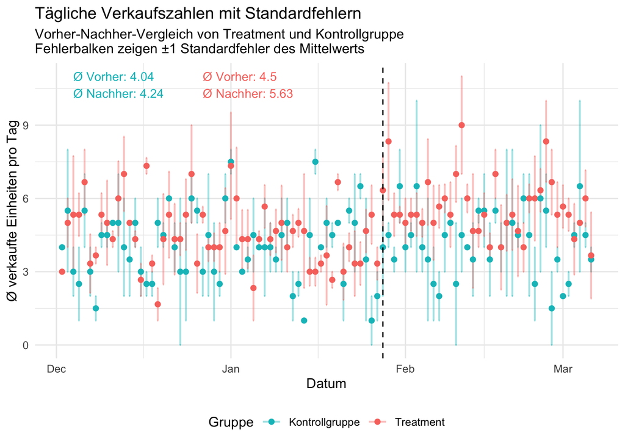

**Interpretation der Grafik**

**Hinweise auf einen möglichen Effekt des natürlichen Experiments**

Die Grafik liefert erste suggestive Hinweise auf einen positiven Effekt der Kostentransparenz auf die Verkaufszahlen der Ledergeldbörsen, für die sie eingeführt wurde. Diese Hinweise ergeben sich aus der Beobachtung der Divergenz der Trends nach der Intervention:

- Vor der Intervention: Die weitgehend parallelen Trends in den durchschnittlichen täglichen Verkaufszahlen beider Gruppen (Kontroll- und Treatment-Gruppe) vor dem 28. Januar 2014 sind ein positives Zeichen. Sie unterstützen die Annahme der parallelen Trends, die für die Gültigkeit eines Difference-in-Differences-Ansatzes von entscheidender Bedeutung ist. Wenn sich die Gruppen vor der Intervention ähnlich verhalten haben, dann können wir Unterschiede in den Verkaufszahlen nach der Intervention, die über die natürlichen Unterschiede hinausgehen, dem Treatment zuschreiben.
- Nach der Intervention: Nach der Einführung der Kostentransparenz sehen wir eine Tendenz, dass die durchschnittlichen täglichen Verkaufszahlen der Treatment-Gruppe im Vergleich zur Kontrollgruppe ein höheres Niveau erreichen oder beibehalten. Während die Kontrollgruppe keine offensichtliche Verbesserung zeigt, scheinen die Verkäufe der Treatment-Gruppe im Schnitt leicht anzusteigen oder zumindest stabiler zu sein. Dieser relative Anstieg in der Treatment-Gruppe, der in der Kontrollgruppe nicht beobachtet wird, ist der Kern des Difference-in-Differences-Gedankens.

Es ist wichtig zu betonen, dass dies visuelle, erste Hinweise sind. Aufgrund der täglichen Schwankungen und der Überlappung der Fehlerbalken ist es mit dieser Grafik allein nicht möglich, definitive kausale Schlüsse zu ziehen oder die statistische Signifikanz des Effekts zu beurteilen. Die Fehlerbalken zeigen den Standardfehler des Mittelwerts, was die Präzision der Schätzung des täglichen Mittelwerts angibt. Eine Überlappung der Fehlerbalken bedeutet nicht zwangsläufig, dass es keinen Effekt gibt, aber eine klare Trennung würde einen stärkeren visuellen Hinweis auf einen signifikanten Unterschied liefern.  
Für eine robustere Schlussfolgerung ist eine formale statistische Analyse mittels eines Difference-in-Differences-Modells (wie in Kapitel 18.1 und 18.2 des genannten Artikels beschrieben) unerlässlich. Diese Analyse würde die durchschnittlichen Unterschiede vor und nach der Intervention in beiden Gruppen quantifizieren und die statistische Signifikanz des “Differenz der Differenzen”-Effekts bestimmen, während sie gleichzeitig die von Ihnen genannten Kontrollvariablen (Seite aufrufe, Inventar) berücksichtigt, um potenzielle Störfaktoren zu isolieren. Die Grafik dient jedoch hervorragend dazu, die zugrundeliegenden Trends zu visualisieren und die Plausibilität der Annahme paralleler Trends zu überprüfen, bevor man sich in die statistische Modellierung vertieft.

22. In der vorherigen Aufgabe haben Sie den Effekt von Kostentransparenz auf die Verkaufszahlen anhand eines deskriptiven Vergleichs untersucht. Dabei haben Sie die durchschnittlich täglich verkauften Einheiten je Treatment vor und nach der Einführung der Transparenzmaßnahme grafisch gegenübergestellt. In dieser Aufgabe sollen Sie diesen Effekt nun ökonometrisch genauer untersuchen, indem Sie den Difference-in-Differences Ansatz in einem Regressionsrahmen anwenden.

Untersuchen Sie den Effekt der Einführung von Kostentransparenz auf die Verkaufszahlen mithilfe einer Difference-in-Differences Regression. Verwenden Sie hierfür Beobachtungen an Werktagen, sowie am Wochenende (Montag bis Sonntag), mit positiven Verkaufszahlen.

Erstellen Sie insgesamt zwei Regressionsmodelle:

- Basismodell ohne Kontrollvariablen
- Modell mit Kontrolle für Wochentagseffekte

Stellen Sie die Ergebnisse anschaulich dar. Beschreiben und interpretieren Sie Ihre Ergebnisse. Gehen Sie insbesondere auf folgende Aspekte ein.

- Wie würden Sie die Größe des Effekts interpretieren, den Sie für `treated:post` erhalten haben?
- Welche Vorteile bringt es, log_units (logarithmierte Verkäufe) als abhängige Variable zu verwenden?
- Können Sie aus Ihrer Schätzung auf einen kausalen Effekt der Kostentransparenz schließen?
- Inwiefern hilft die Kontrolle für Wochentage dabei, Verzerrungen in der Schätzung zu vermeiden?
- Würden Sie auf Basis Ihrer Analyse eine Empfehlung zur Beibehaltung oder Ausweitung der Kostentransparenz geben?
- Worin könnten ihrer Ansicht nach Probleme liegen bei der Betrachtung eines natürlichen Experiments, die die Ergebnisse verzerren könnten?

*Hinweis 1:* Nutzen Sie für die Schätzung die `feols()`-Funktion aus dem fixest-Paket.

*Hinweis 2:* Nutzen Sie die logarithmierten täglichen Verkaufszahlen als abhängige Variable.

**Regressionsergebnisse: Einfluss von Kostentransparenz auf log(Verkäufe)**

| Variable | Ohne Wochentage | Mit Wochentagseffekten |
| --- | --- | --- |
| Log. Verkaufszahlen | 1.604 [1.564, 1.645]*** | 1.602 [1.508, 1.696]*** |
| Kostentransparenz | 0.229 [0.146, 0.311]*** | 0.228 [0.146, 0.310]*** |
| Dienstag | NA | 0.019 [-0.110, 0.149] |
| Mittwoch | NA | 0.100 [-0.030, 0.229] |
| Donnerstag | NA | -0.060 [-0.190, 0.070] |
| Freitag | NA | 0.036 [-0.096, 0.168] |
| Samstag | NA | 0.008 [-0.125, 0.140] |
| Sonntag | NA | -0.088 [-0.220, 0.045] |
| R² | 0.06 | 0.08 |
| Adj. R² | 0.058 | 0.067 |
| AIC | 448.47 | 450.08 |
| BIC | 456.78 | 483.31 |
| Beobachtungen | 470 | 470 |

*Signifikanz: *** p < 0.001, ** p < 0.01, * p < 0.05*

[figure not shown]

**Wie würden Sie die Größe des Effekts interpretieren, den Sie für did_treat erhalten haben?**

**Welche Vorteile bringt es, log_units (logarithmierte Verkäufe) als abhängige Variable zu verwenden?**

Die Verwendung von log_units (logarithmierten Verkäufen) als abhängige Variable in einer Regressionsanalyse bietet mehrere wesentliche Vorteile, insbesondere bei der Modellierung von Verkaufsdaten:

- Interpretation als prozentuale Effekte (Elastizitäten): Wie in der vorherigen Antwort erläutert, können Koeffizienten bei einer logarithmierten abhängigen Variable direkt als prozentuale Veränderungen interpretiert werden. Dies ist oft intuitiver und aussagekräftiger, wenn man über die Auswirkungen auf Verkaufszahlen spricht. Ein Anstieg um 25% ist beispielsweise leichter zu interpretieren und zu vergleichen als ein Anstieg um X Einheiten, dessen relative Bedeutung vom Basisniveau abhängt.
- Umgang mit Schiefe und Heteroskedastizität: Verkaufsdaten sind oft rechtsschief verteilt (d.h., es gibt viele Tage mit wenigen Verkäufen und wenige Tage mit sehr hohen Verkäufen) und weisen Heteroskedastizität auf (d.h., die Varianz der Fehlerterme ist nicht konstant über alle Werte der unabhängigen Variablen hinweg). Die Logarithmierung kann dazu beitragen, die Verteilung der abhängigen Variable zu normalisieren und die Heteroskedastizität zu reduzieren, was die Annahmen der linearen Regression (insbesondere für die Inferenz) besser erfüllt. Eine normalere Verteilung und konstantere Varianz führen zu robusteren und effizienteren Schätzungen.
- Abbildung von multiplikativen Effekten: Oft haben ökonomische Effekte eine multiplikative und keine additive Natur. Beispielsweise könnte eine Marketingmaßnahme die Verkäufe nicht um 10 Einheiten, sondern um 10% steigern, unabhängig vom Ausgangsniveau. Die Log-Transformation ermöglicht es, solche multiplikativen Beziehungen linear zu modellieren.
- ermeidung von negativen Vorhersagen: Da Verkaufszahlen naturgemäß nicht negativ sein können, stellt die Logarithmierung sicher, dass die vorhergesagten Werte (nach Rücktransformation) immer positiv sind (e<sup>x</sup> ist immer positiv).

**Schließung auf einen kausalen Effekt der Kostentransparenz durch die Schätzung**

Basierend auf den vorliegenden Schätzungen und der zugrundeliegenden Designstrategie (natürliches Experiment mit DiD-Ansatz) ja, es gibt starke Hinweise auf einen kausalen Effekt der Kostentransparenz.  
Die Argumentation für kausale Schlussfolgerungen im Rahmen eines DiD-Ansatzes beruht auf mehreren Säulen, die in diesem Setup gut berücksichtigt sind:

- Natürliches Experiment: Die zufällige (oder zumindest unbeabsichtigte und damit exogene) Zuteilung der Behandlung (Kostentransparenz für bestimmte Farben) aufgrund eines Fehlers macht das Experiment “natürlich”. Dies reduziert die Sorge vor Endogenität, die bei geplanten Experimenten oder reinen Beobachtungsstudien oft ein Problem darstellt.
- Difference-in-Differences Design: Dieser Ansatz ist speziell darauf ausgelegt, kausale Effekte zu identifizieren. Er kontrolliert für:
  - Zeitkonstante, unbeobachtete Unterschiede zwischen den Gruppen: Unterschiede zwischen den Wallet-Farben (z.B. inhärente Beliebtheit, obwohl Sie diese auch kontrollieren) werden durch die erste Differenz (vorher/nachher in der Behandlungsgruppe vs. vorher/nachher in der Kontrollgruppe) eliminiert.
  - Zeitlich variierende, aber für beide Gruppen gemeinsame Faktoren: Saisonale Effekte, allgemeine Markttrends, allgemeine Werbemaßnahmen des Händlers, etc., die beide Gruppen gleichermaßen beeinflussen würden, werden durch den Vergleich mit der Kontrollgruppe eliminiert. Der Anstieg des Weihnachtsgeschäfts und der Rückgang danach, den man in den Grafiken sah, wäre so ein Faktor, der durch DiD herausgerechnet wird.
- Parallel-Trends-Annahme: Dies ist die kritischste Annahme. Die vorherigen grafischen Analysen (insbesondere die der wöchentlichen Durchschnitte) zeigten visuelle Hinweise, dass die Verkaufszahlen der beiden Gruppen vor der Einführung der Kostentransparenz einem ähnlichen Trend folgten. Die Regressionsergebnisse selbst zeigen einen signifikanten Effekt des DiD-Terms, was unter der Annahme gültiger Paralleltrends als kausal interpretiert werden kann. Wenn die Parallel-Trends-Annahme verletzt wäre (d.h., die Gruppen hätten sich auch ohne die Intervention unterschiedlich entwickelt), wäre die kausale Interpretation gefährdet. Die visuelle Inspektion vor der Intervention ist hier der beste Indikator.
- Kontrollvariablen: Die Hinzunahme von Kontrollvariablen (wie Wochentagseffekte und den bereits genannten Seitenaufrufen/Inventar in der Studienbeschreibung) hilft, potenzielle verzerrende Faktoren weiter zu isolieren, die spezifisch für eine Gruppe sind und sich zeitlich verändern könnten, aber nicht direkt mit der Intervention zusammenhängen.

Solange die Parallel-Trends-Annahme vernünftigerweise aufrechterhalten werden kann (was die Grafiken unterstützen), ist die Schätzung von did_treat als kausaler Effekt der Kostentransparenz auf die Verkaufszahlen zu interpretieren.

**Inwiefern hilft die Kontrolle für Wochentage dabei, Verzerrungen in der Schätzung zu vermeiden?**

Die Kontrolle für Wochentagseffekte (durch die Aufnahme von factor(weekday) in das Modell) hilft in mehrfacher Hinsicht, Verzerrungen in der Schätzung des did_treat-Koeffizienten zu vermeiden:

- Heterogene Wochentagsmuster: Verkaufszahlen weisen oft starke Wochentagsmuster auf. Zum Beispiel könnten die Verkäufe am Wochenende höher oder niedriger sein als an Werktagen, oder Montags könnten die Verkäufe nachlassen, während sie Freitags ansteigen. Wenn die Verteilung der Wochentage in der Pre- und Post-Periode (oder zwischen den Gruppen) nicht gleichmäßig ist oder wenn die Einführung der Kostentransparenz genau auf einen Tag fällt, der typischerweise ungewöhnlich hohe oder niedrige Verkaufszahlen aufweist, könnte dies die Schätzung des Effekts verzerren.
- Eliminierung von unsystematischen Schwankungen: Durch die explizite Modellierung der Wochentagseffekte (z.B. als fixe Effekte oder Dummy-Variablen für jeden Wochentag) wird ein Teil der täglichen Variabilität in den Verkaufszahlen erfasst und aus dem Fehlerterm entfernt. Dies führt zu präziseren Schätzungen der anderen Koeffizienten (insbesondere des did_treat-Koeffizienten), da das “Rauschen” im Modell reduziert wird. Die Standardfehler werden in der Regel kleiner, was die statistische Power erhöht, signifikante Effekte zu erkennen. In der Tabelle sieht man, dass das R2 des Modells mit Wochentagseffekten (0.080) höher ist als das des Basismodells (0.060), was darauf hindeutet, dass die Wochentage tatsächlich einen Teil der Varianz erklären.
- Robuster gegenüber der Parallel-Trends-Annahme: Obwohl die primäre DiD-Annahme die Parallel-Trends sind, können feine Unterschiede in den Wochentagsmustern zwischen den Gruppen oder über die Zeit hinweg diese Annahme untergraben. Durch die Kontrolle für Wochentagseffekte wird sichergestellt, dass der geschätzte did_treat-Effekt nicht durch solche systematischen Wochentagsmuster verzerrt wird, die möglicherweise nicht vollständig durch die DiD-Struktur allein abgefangen werden. Es stellt sicher, dass der Effekt der Kostentransparenz nicht versehentlich Effekte von beispielsweise “Sonntags-Verkaufseinbrüchen” mitbeinhaltet, die zufällig nach der Intervention häufiger auftreten.

**Empfehlung zur Beibehaltung oder Ausweitung der Kostentransparenz**

Auf Basis der Analyse würde ich eine klare Empfehlung zur Beibehaltung und potenziellen Ausweitung der Kostentransparenz geben.  
Die Gründe dafür sind:

- Statistisch signifikanter positiver Effekt: Die Regressionen zeigen einen robusten und statistisch hochsignifikanten positiven Effekt der Kostentransparenz auf die Verkaufszahlen. Ein Anstieg der Verkäufe um etwa 25% ist wirtschaftlich bedeutsam und kein trivialer Wert.
- Kausale Interpretation: Der Difference-in-Differences-Ansatz, gestützt durch die visuelle Evidenz für die Parallel-Trends-Annahme und die Kontrolle für relevante Störfaktoren (wie Wochentage), ermöglicht eine kausale Interpretation. Das bedeutet, dass der beobachtete Anstieg der Verkaufszahlen tatsächlich auf die Einführung der Kostentransparenz zurückgeführt werden kann und nicht auf andere, unbeobachtete Faktoren.
- Vorteile der Log-Transformation: Die Verwendung von log_units liefert uns eine prozentuale Interpretation des Effekts, die sich gut verallgemeinern lässt. Ein 25%-iger Anstieg ist eine relativ konstante Steigerung, die unabhängig vom absoluten Verkaufsniveau ist.
- Geringe Implementierungskosten: Die Implementierung einer Infografik auf Produktseiten ist in der Regel mit relativ geringen einmaligen Kosten verbunden. Angesichts des beträchtlichen Umsatzanstiegs erscheint das Kosten-Nutzen-Verhältnis sehr vorteilhaft.

Empfehlung:

- Beibehaltung: Die Kostentransparenz sollte für die Farben beibehalten werden, bei denen sie bereits implementiert ist (burgundy, black, grey).
- Ausweitung: Es gibt starke Gründe, die Kostentransparenz-Infografik auch auf die bisher nicht transparenten Farben (bone und tan) und möglicherweise auf weitere Produkte im Sortiment des Händlers auszuweiten, sofern ähnliche Effekte erwartet werden können und die Kostenstruktur dies zulässt. Eine weitere Überlegung wäre eine A/B-Testung bei neuen Produkten, um die Robustheit des Effekts weiter zu überprüfen.

**Probleme bei der Betrachtung eines natürlichen Experiments, die die Ergebnisse verzerren könnten**

Das Wissen um diese potenziellen Probleme ist entscheidend, um die Robustheit der Ergebnisse zu bewerten und die Grenzen der kausalen Schlussfolgerungen zu verstehen.

# Literatur

Mohan, B., Buell, R. W., & John, L. K. (2020). Lifting the veil: The benefits of cost transparency. Marketing Science, 39(6), 1105-1121. https://doi.org/10.1287/mksc.2019.1200

# Anhang

## Mediator

Im Rahmen von Mediationen ist der Mediator eine Variable, die den erklärenden Zusammenhang zwischen einer unabhängigen und einer abhängigen Variable vermittelt. Dabei wird untersucht, inwieweit der Einfluss der unabhängigen Variablen (z.B. Kostentransparenz) auf die abhängige Variable (z.B. Kaufabsicht) über einen vermittelnden Mechanismus - wie das Vertrauen der Kunden - erfolgt.

1. **Mediatoreffekt**: Der Mediatoren-Effekt, oft als ACME (Average Causal Mediation Effect) bezeichnet, beschreibt den indirekten Effekt, den die unabhängige Variable auf die abhängige Variable über den Mediator ausübt. Ist dieser Effekt signifikant, signalisiert dies, dass ein wesentlicher Teil des gesamten Einflusses über den vermittelnden Mechanismus läuft. Gleichzeitig kann ein nicht-signifikanter direkter Effekt (ADE - Average Direct Effect) darauf hindeuten, dass der Mediator den hauptsächlichen Erklärungsmechanismus darstellt.
2. **Funktion und Wirkung des Mediators**: Analog zum Konzept der signalgebenden Funktion bei Statussymbolen - deren Wert unter anderem von der Exklusivität und dem sozialen Kontext abhängt - fungiert der Mediator als vermittelnder Kanal, der erklärt, wie und warum der ursprüngliche Zusammenhang zwischen zwei Variablen zustande kommt. Der Mediator „überträgt“ quasi den Effekt der unabhängigen Variable auf die abhängige Variable. Dadurch kann in Modellen, in denen der direkte Zusammenhang zwischen der unabhängigen und der abhängigen Variable durch die Einbeziehung des Mediators verschwindet oder abgeschwächt wird, abgeleitet werden, dass der Mechanismus über den Mediator läuft. Dies ermöglicht ein tieferes Verständnis der zugrundeliegenden psychologischen Prozesse - etwa wie das Vertrauen der Kunden die Wirkung von Kostentransparenz auf deren Kaufabsicht vermittelt.

Zusammengefasst spielt der Mediator eine zentrale Rolle bei der Aufklärung der kausalen Mechanismen, indem er als vermittelnder Faktor zwischen Ursache und Wirkung identifiziert wird. Die signifikante Vermittlung über den Mediator zeigt, dass nicht allein das Vorhandensein von Kostentransparenz entscheidend ist, sondern auch, inwiefern diese Transparenz das Vertrauen stärkt - was wiederum maßgeblich die Kaufabsicht beeinflusst. So liefert die Mediationsanalyse wertvolle Einsichten, die über einfache bivariate Zusammenhänge hinausgehen und die Komplexität kausaler Mechanismen innerhalb von sozialen oder marktorientierten Prozessen sichtbar machen.